# Investigating the genetic and environmental aetiologies of non-suicidal and suicidal self-harm: A twin study

```r
sqrt_path_e<-mxAlgebra(expression=sqrt(e2), name="path_e")
NSSH_e2 <-mxAlgebra( expression= path_e[2,2], name="NSSH_e")
SSH_e2  <-mxAlgebra( expression= path_e[3,3], name="SSH_e")

#rA
raNSSHcSMOK<-mxAlgebra(expression=Ra[2,1], name="rA_NSSH_cSMOK")
raSSHcSMOK<-mxAlgebra(expression=Ra[3,1], name="rA_SSH_cSMOK")
#rC
rcNSSHcSMOK<-mxAlgebra(expression=Rc[2,1], name="rC_NSSH_cSMOK")
rcSSHcSMOK<-mxAlgebra(expression=Rc[3,1], name="rC_SSH_cSMOK")
#rE
reNSSHcSMOK<-mxAlgebra(expression=Re[2,1], name="rE_NSSH_cSMOK")
reSSHcSMOK<-mxAlgebra(expression=Re[3,1], name="rE_SSH_cSMOK")


# Algebra for expected Variance/Covariance Matrices in MZ & DZ twins
covMZ   <- mxAlgebra( expression= rbind( cbind(A+C+E , A+C),
                                       cbind(A+C  , A+C+E)), name="ExpCovMZ" )
covDZ   <- mxAlgebra( expression= rbind( cbind(A+C+E      , 0.5%x%A+C),
                                       cbind(0.5%x%A+C , A+C+E)), name="ExpCovDZ" )
# Data objects for Multiple Groups
dataMZ   <- mxData( observed=mzData, type="raw" )
dataDZ   <- mxData( observed=dzData, type="raw" )

# Objective objects for Multiple Groups
objMZ   <- mxExpectationNormal( covariance="ExpCovMZ", means="ExpMean", dimnames=selVars, thresholds="ExpThres", threshnames=c('cSMOK1', 'NSSH1', 'SSH1', 'cSMOK2', 'NSSH2', 'SSH2')  )
objDZ   <- mxExpectationNormal( covariance="ExpCovDZ", means="ExpMean", dimnames=selVars, thresholds="ExpThres", threshnames=c('cSMOK1', 'NSSH1', 'SSH1', 'cSMOK2', 'NSSH2', 'SSH2')  )

fitFunction <- mxFitFunctionML()

# Combine Groups
pars        <- list( pathA, pathC, pathE, covA, covC, covE, covP, StA, StC, StE, matI, rph, rA, rC, rE,
               rphace_cSMOK_NSSH,rphace_cSMOK_SSH,rphace_NSSH_SSH,
               sqrt_path_a, NSSH_h2, SSH_h2,
               sqrt_path_c, NSSH_c2, SSH_c2,
               sqrt_path_e, NSSH_e2, SSH_e2,
               raNSSHcSMOK,raSSHcSMOK,rcNSSHcSMOK,rcSSHcSMOK,reNSSHcSMOK,reSSHcSMOK)

modelMZ <- mxModel( pars, obsAge211, obsAge212,obsAge161,obsAge162, obsSex1, obsSex2 , Mean, Tr, inc, Thres,
                    betaA21,betaA16, betaS, covMZ, dataMZ, objMZ, fitFunction, varL1, varL2, varL3, name="MZ" )
modelDZ <- mxModel( pars, obsAge211, obsAge212,obsAge161,obsAge162, obsSex1, obsSex2 , Mean, Tr, inc, Thres,
                    betaA21,betaA16, betaS, covDZ, dataDZ, objDZ, fitFunction, name="DZ" )
minus2ll    <- mxAlgebra( expression=MZ.objective + DZ.objective, name="m2LL" )
obj     <- mxFitFunctionAlgebra( "m2LL" )

#confidence intervals
Conf1       <- mxCI (c('Rph[2,1]','Rph[3,1]'))
Conf2       <- mxCI ('Ra[2,1]')
Conf3       <- mxCI ('Ra[3,1]')
Conf4       <- mxCI ('Rc[2,1]')
Conf5       <- mxCI ('Rc[3,1]')
Conf6   <- mxCI ('Re[2,1]')
Conf7   <- mxCI ('Re[3,1]')


AceModel1   <- mxModel( "ACE", pars, modelMZ, modelDZ, minus2ll, obj, Conf1)
AceModel2   <- mxModel( "ACE", pars, modelMZ, modelDZ, minus2ll, obj, Conf2)
AceModel3   <- mxModel( "ACE", pars, modelMZ, modelDZ, minus2ll, obj, Conf3)
AceModel4   <- mxModel( "ACE", pars, modelMZ, modelDZ, minus2ll, obj, Conf4)
AceModel5   <- mxModel( "ACE", pars, modelMZ, modelDZ, minus2ll, obj, Conf5)
AceModel6   <- mxModel( "ACE", pars, modelMZ, modelDZ, minus2ll, obj, Conf6)
AceModel7   <- mxModel( "ACE", pars, modelMZ, modelDZ, minus2ll, obj, Conf7)

# 3) RUN AceModel
AceFit1 <- mxTryHardOrdinal(AceModel1, intervals=T) #fit = 25519.628
AceFit2 <- mxTryHardOrdinal(AceModel2, intervals=T)
AceFit3 <- mxTryHardOrdinal(AceModel3, intervals=T)
AceFit4 <- mxTryHardOrdinal(AceModel4, intervals=T)
AceFit5 <- mxTryHardOrdinal(AceModel5, intervals=T)
AceFit6 <- mxTryHardOrdinal(AceModel6, intervals=T)
AceFit7 <- mxTryHardOrdinal(AceModel7, intervals=T)

(AceSum1    <- summary(AceFit1,verbose=T))
(AceSum2    <- summary(AceFit2,verbose=T))
(AceSum3    <- summary(AceFit3,verbose=T))
(AceSum4    <- summary(AceFit4,verbose=T))
(AceSum5    <- summary(AceFit5,verbose=T))
(AceSum6    <- summary(AceFit6,verbose=T))
(AceSum7    <- summary(AceFit7,verbose=T))


#get the estimates and CIs
CI1 <- AceSum1$CI
CI2 <- AceSum2$CI
CI3 <- AceSum3$CI
CI4 <- AceSum4$CI
CI5 <- AceSum5$CI
CI6 <- AceSum6$CI
CI7 <- AceSum7$CI

tot_CI<-rbind(CI1,CI2,CI3,CI4,CI5,CI6,CI7)

#evaluate the contents
mxEval(MZ.ExpCovMZ, AceFit1)
mxEval(DZ.ExpCovDZ, AceFit1)
mxEval(ACE.h2, AceFit1)
mxEval(ACE.c2, AceFit1)
mxEval(ACE.e2, AceFit1)
mxEval(ACE.Ra, AceFit1)
mxEval(ACE.Rc, AceFit1)
mxEval(ACE.Re, AceFit1)
mxEval(ACE.Rph, AceFit1)
mxEval(ACE.RphACE_cSMOK_NSSH, AceFit1)/mxEval(ACE.Rph, AceFit1)[2,1]*100
mxEval(ACE.RphACE_cSMOK_SSH, AceFit1)/mxEval(ACE.Rph, AceFit1)[3,1]*100
mxEval(ACE.V,AceFit1)

#get the proportion explained by A,C and E in the phenotypic correlation
proportion<-as.data.frame(rbind((mxEval(ACE.RphACE_cSMOK_NSSH, AceFit1)/mxEval(ACE.Rph, AceFit1)[2,1])*100,
                                (mxEval(ACE.RphACE_cSMOK_SSH, AceFit1)/mxEval(ACE.Rph, AceFit1)[3,1])*100,
                                mxEval(ACE.RphACE_cSMOK_NSSH, AceFit1),
                                mxEval(ACE.RphACE_cSMOK_SSH, AceFit1)),
                          row.names=c("NSSH%","SSH%", "NSSH","SSH"))
colnames(proportion)<-c("A","C","E")


proportion

#constrain the model
Sub1Model   <- mxModel(AceModel1, name="sub1",
                     mxConstraint(MZ.rA_NSSH_cSMOK==MZ.rA_SSH_cSMOK, name="rA_con"),
                     mxConstraint(MZ.rC_NSSH_cSMOK==MZ.rC_SSH_cSMOK, name="rC_con"),
                     mxConstraint(MZ.rE_NSSH_cSMOK==MZ.rE_SSH_cSMOK, name="rE_con"))

Sub1Fit     <- mxTryHardOrdinal(Sub1Model, intervals = F)

(Sub1Sum    <- summary(Sub1Fit))

mxEval(MZ.NSSH_a,Sub1Fit);mxEval(MZ.SSH_a,Sub1Fit)
mxEval(MZ.NSSH_c,Sub1Fit);mxEval(MZ.SSH_c,Sub1Fit)
mxEval(MZ.NSSH_e,Sub1Fit);mxEval(MZ.SSH_e,Sub1Fit)

mxEval(MZ.path_a,Sub1Fit);mxEval(MZ.path_c,Sub1Fit);mxEval(MZ.path_e,Sub1Fit)

mxEval(MZ.Ra,Sub1Fit);mxEval(MZ.Rc,Sub1Fit);mxEval(MZ.Re,Sub1Fit)

mxEval(MZ.h2,Sub1Fit)

### compare with ACE model
comparison <- mxCompare(AceFit1,Sub1Fit)


library(xlsx)

## 6) save the results

setwd("../results")
save.image(file="Tri_LT_NSSH_SSH_cSMOK_SLSQP_ACE_04_June_2020.RData")
# save the estimates and their confidence intervals
write.xlsx(tot_CI, file="trivariate_estimates_with_CI_04_June_2020.xlsx",
           sheetName="cSMOK", append=TRUE)
```

```r
# save the proportions
write.xlsx(proportion, file="trivariate_proportion_04_June_2020.xlsx",
           sheetName="cSMOK", append=TRUE)


# save the results of the chi-square test
write.xlsx(comparison, file="trivariate_constrained_results_04_June_2020.xlsx",
           sheetName="cSMOK", append=TRUE)
```

### cCANN

```r
rm(list=ls())
Sys.setenv(OMP_NUM_THREADS=parallel::detectCores()) #this has to be before loading the library OpenMx

require(OpenMx);require(psych);require(foreign);require(tidyverse);require(polycor)
mxOption(NULL, "Default optimizer", "SLSQP") # SLSQP is a better optimizer for ordinal data
self_harm_data=read.spss("427 Kai Lim self harm 250919.sav",verbose=T,to.data.frame = T)
hetcor(self_harm_data$pcbhdrug121, self_harm_data$u1cslfh021)$correlations #0.12
hetcor(self_harm_data$pcbhdrug131, self_harm_data$u1cslfh021)$correlations #0.19
hetcor(self_harm_data$pcbhdrug151, self_harm_data$u1cslfh021)$correlations #0.18
table(self_harm_data$pcbhdrug131);table(self_harm_data$pcbhdrug151)

str(self_harm_data);class(self_harm_data)
plot(self_harm_data$pcbhdrug151) #how many times using cannabis - more normally distributed and makes more sense
                                 #using this variable, but need to recode from "no" in previous question
plot(self_harm_data$pcbhdrug131) #how often using cannabis

self_harm_data_c<-self_harm_data %>%
  filter(exclude1==0 & exclude2 ==0)%>% #exclude those with medical conditions etc
  select(randomfamid,randomtwinid,u1cslfh021,u1cslfh022,u1cslfh031,u1cslfh032,u1cslfh041,u1cslfh042,pcbhdrug121, pcbhdrug122, pcbhdrug151,pcbhdrug152,x3zygos,u1cage1,u1cage2,pcbhage1,pcbhage2, sex1,sex2, random)%>%
  mutate_if(is.factor, as.numeric) #import as numeric values for all columns

#fill in co-twin's age as proxy
self_harm_data_c <- mutate(self_harm_data_c, age_211 = ifelse(is.na(u1cage1),u1cage2 , u1cage1))
self_harm_data_c <- mutate(self_harm_data_c, age_212 = ifelse(is.na(u1cage2),u1cage1 , u1cage2))

self_harm_data_c <- mutate(self_harm_data_c, age_161 = ifelse(is.na(pcbhage1),pcbhage2 , pcbhage1))
self_harm_data_c <- mutate(self_harm_data_c, age_162 = ifelse(is.na(pcbhage2),pcbhage1 , pcbhage2))

#recode so that no="0"
self_harm_data_c$u1cslfh021=self_harm_data_c$u1cslfh021-1
self_harm_data_c$u1cslfh022=self_harm_data_c$u1cslfh022-1
self_harm_data_c$u1cslfh031=self_harm_data_c$u1cslfh031-1
self_harm_data_c$u1cslfh032=self_harm_data_c$u1cslfh032-1
self_harm_data_c$u1cslfh041=self_harm_data_c$u1cslfh041-1
self_harm_data_c$u1cslfh042=self_harm_data_c$u1cslfh042-1

table(self_harm_data_c$u1cslfh022)
table(self_harm_data_c$u1cslfh021)
table(self_harm_data_c$u1cslfh032)
table(self_harm_data_c$u1cslfh031)
table(self_harm_data_c$u1cslfh042)
table(self_harm_data_c$u1cslfh041)

table(self_harm_data_c$pcbhdrug121)
table(self_harm_data_c$pcbhdrug151)

#bring zeros from SH question into NSSH and SSH.
self_harm_data_c <- mutate(self_harm_data_c, NSSH1 = ifelse(is.na(u1cslfh031)&u1cslfh021==0,u1cslfh021,u1cslfh031))
self_harm_data_c <- mutate(self_harm_data_c, NSSH2 = ifelse(is.na(u1cslfh032)&u1cslfh022==0,u1cslfh022,u1cslfh032))
self_harm_data_c <- mutate(self_harm_data_c, SSH1 = ifelse(is.na(u1cslfh041)&u1cslfh021==0,u1cslfh021,u1cslfh041))
self_harm_data_c <- mutate(self_harm_data_c, SSH2 = ifelse(is.na(u1cslfh042)&u1cslfh022==0,u1cslfh022,u1cslfh042))

#bring zeros from never used cannabis into number of times using cannabis
self_harm_data_c <- mutate(self_harm_data_c, cCANN1 = ifelse(is.na(pcbhdrug151)&pcbhdrug121==0,pcbhdrug121,pcbhdrug151))
self_harm_data_c <- mutate(self_harm_data_c, cCANN2 = ifelse(is.na(pcbhdrug152)&pcbhdrug122==0,pcbhdrug122,pcbhdrug152))

table(self_harm_data_c$u1cslfh021)
table(self_harm_data_c$u1cslfh022)

table(self_harm_data_c$u1cslfh031)
table(self_harm_data_c$u1cslfh032)
table(self_harm_data_c$NSSH1)
table(self_harm_data_c$NSSH2)


table(self_harm_data_c$u1cslfh041)
table(self_harm_data_c$u1cslfh042)
table(self_harm_data_c$SSH1)
table(self_harm_data_c$SSH2)

table(self_harm_data_c$pcbhdrug121)
table(self_harm_data_c$pcbhdrug122)
table(self_harm_data_c$pcbhdrug151)
table(self_harm_data_c$pcbhdrug152)
table(self_harm_data_c$cCANN1)
table(self_harm_data_c$cCANN2)
plot(self_harm_data_c$cCANN1)
head(self_harm_data_c)

dim(self_harm_data);dim(self_harm_data_c)


#Make the integer variables ordered factors
self_harm_data_c$NSSH1<-mxFactor(self_harm_data_c$NSSH1, levels=c(0:4) )
self_harm_data_c$NSSH2<-mxFactor(self_harm_data_c$NSSH2, levels=c(0:4) )
self_harm_data_c$SSH1<-mxFactor(self_harm_data_c$SSH1, levels=c(0:4) )
self_harm_data_c$SSH2<-mxFactor(self_harm_data_c$SSH2, levels=c(0:4) )
self_harm_data_c$cCANN1<-mxFactor(self_harm_data_c$cCANN1, levels=c(0:5) )
self_harm_data_c$cCANN2<-mxFactor(self_harm_data_c$cCANN2, levels=c(0:5) )

str(self_harm_data_c)

library(polycor) #check phenotypic correlation
hetcor(self_harm_data_c$cCANN1, self_harm_data_c$NSSH1)$correlations #0.23
hetcor(self_harm_data_c$cCANN1, self_harm_data_c$SSH1)$correlations #without covariates, 0.22
hetcor(self_harm_data_c$SSH1, self_harm_data_c$NSSH1)$correlations # 0.87, same as in other less complex models.


nv  <- 3        # number of variables per twin
nvo <-3     #number of ordinal variables per twin
nvc <-nv-nvo  #number of continuous variables per twin
poso <- nvc+1 #position where ordinal variables start
ntv     <- nv*2 # number of variables per pair
nth <- 5        # number of max thresholds
nlower  <- ntv*(ntv+1)/2    # number of free elements in a lower matrix ntv*ntv
ncor    <-(nv*(nv+1)/2)-nv  # number of free elements in a correlation matrix nv*nv
ninc <-
vars        <-c('cCANN','NSSH', 'SSH')
selVars <-c('cCANN1', 'NSSH1', 'SSH1', 'cCANN2', 'NSSH2', 'SSH2')
useVars <-c('cCANN1', 'NSSH1', 'SSH1', 'cCANN2', 'NSSH2', 'SSH2', 'age_211', 'age_212','age_161','age_162', 'sex1','sex2')

# Select Data for Analysis
mzData  <- subset(self_harm_data_c, x3zygos==1 & random==1 & !is.na(age_211&age_212) &!is.na(age_161&age_162) &!is.na(sex1&sex2), useVars) #select only one twin from each pair because of double entry method
dzData  <- subset(self_harm_data_c, x3zygos!=1 & random==1 & !is.na(age_211&age_212) &!is.na(age_161&age_162) &!is.na(sex1&sex2), useVars)
describe(mzData)
describe(dzData)
nth-1 #number of max increments
ncovariates <- 2 #number of covariates




# 2)    Specify ACE Model, with ONE overall set of Means, ONE overall Threshold on IQ liability
```

```r
# To create Labels for Lower Triangular Matrices
LabThMZ <-c('Tmz_11','imz_11','imz_12','imz_13','imz_14',
            'Tmz_21','imz_21','imz_22','imz_23','imz_24',
            'Tmz_31','imz_31','imz_32','imz_33','imz_34')           # THs for var 1 and 2 for a twin individual (mz)
#LabCorMZ   <-c('r21','rMZ1','MZxtxt','MZxtxt','rMZ2','r21')
LabThDZ <-c('Tmz_11','imz_11','imz_12','imz_13','imz_14',
            'Tmz_21','imz_21','imz_22','imz_23','imz_24',
            'Tmz_31','imz_31','imz_32','imz_33','imz_34')           # THs for var 1 and 2 for a twin individual (mz)
#LabCorDZ   <-c('r21','rDZ1','DZxtxt','DZxtxt','rDZ2','r21')
LabCovA21   <-c(rep('BageThNULL21',5),rep('BageThNSSH21',4),'BageThNULL21',rep('BageThSSH21',4),'BageThNULL21')
LabCovA16   <-c(rep('BageThDRUG16',5),rep('BageThNULL16',5),rep('BageThNULL16',5))
LabCovS <-c(rep('BsexThDRUG',5),rep('BsexThNSSH',4),'BsexThNULL',rep('BsexThSSH',4),'BsexThNULL')

StTH        <-c(6.17,0.52,0.27,0.27,0.27,
            -0.20,0.45,0.19,0.15,0,
            0.88,0.55,0.25,0.16, 0)
ThPatSH     <-c(rep(T,5),rep(T,4),F,rep(T,4),F)
aLabs <- paste("a", do.call(c, sapply(seq(1, nv), function(x){ paste(x:nv, x,sep="") })), sep="")
cLabs <- paste("c", do.call(c, sapply(seq(1, nv), function(x){ paste(x:nv, x,sep="") })), sep="")
eLabs <- paste("e", do.call(c, sapply(seq(1, nv), function(x){ paste(x:nv, x,sep="") })), sep="")

# Matrices to store a, c, and e Path Coefficients
pathA   <- mxMatrix( type="Lower", nrow=nv, ncol=nv, free=TRUE, values=c(1.0,0.19,0.23,0.68,0.58,0.23), labels=aLabs, name="a" )
pathC   <- mxMatrix( type="Lower", nrow=nv, ncol=nv, free=TRUE, values=c(0.74,0.18,0.19,0.002,0.002,0.005), labels=cLabs, name="c" )
pathE   <- mxMatrix( type="Lower", nrow=nv, ncol=nv, free=TRUE, values=c(4.43,0.09,0.08,0.67,0.56,0.43), labels=eLabs, name="e" )

# # Define definition variables to hold the Covariates

obsAge211   <- mxMatrix( type="Full", nrow=1, ncol=1, free=F, labels=c("data.age_211"), name="Age211")
obsAge212   <- mxMatrix( type="Full", nrow=1, ncol=1, free=F, labels=c("data.age_212"), name="Age212")
obsAge161   <- mxMatrix( type="Full", nrow=1, ncol=1, free=F, labels=c("data.age_161"), name="Age161")
obsAge162   <- mxMatrix( type="Full", nrow=1, ncol=1, free=F, labels=c("data.age_162"), name="Age162")
obsSex1 <- mxMatrix( type="Full", nrow=1, ncol=1, free=F, labels=c("data.sex1"), name="Sex1")
obsSex2 <- mxMatrix( type="Full", nrow=1, ncol=1, free=F, labels=c("data.sex2"), name="Sex2")

#effect of age and sex on ordinal variable
value_sex<-c(rep(0.2,5),rep(0.2,4),0,rep(0.2,4),0)
free_sex <-c(rep(T,5),rep(T,4),F,rep(T,4),F)

value_age16<-c(rep(0.2,5),rep(0,5),rep(0,5))
free_age16 <-c(rep(T,5),rep(F,5),rep(F,5))

value_age21<-c(rep(0,5),rep(0.2,4),0,rep(0.2,4),0)
free_age21 <-c(rep(F,5),rep(T,4),F,rep(T,4),F)

betaA21     <-mxMatrix( type="Full", nrow=nth, ncol=nvo, free=free_age21, values=value_age21, labels=LabCovA21, name="BageTH21" )
betaA16     <-mxMatrix( type="Full", nrow=nth, ncol=nvo, free=free_age16, values=value_age16, labels=LabCovA16, name="BageTH16" )
betaS       <-mxMatrix( type="Full", nrow=nth, ncol=nvo, free=free_sex, values=value_sex, labels=LabCovS, name="BsexTH" )


#mean and thresholds, no mean if all variables are ordinals
Mean        <-mxMatrix( type="Zero", nrow=1, ncol=ntv, name="ExpMean" )

Tr      <-mxMatrix( type="Full", nrow=nth, ncol=nvo, free=ThPatSH, values=StTH, lbound=-4, ubound=100,
                 labels=LabThMZ, name="Th")

inc     <-mxMatrix( type="Lower",nrow=nth, ncol=nth, free=F, values=1, name="Low")

Thres   <-mxAlgebra( expression= cbind(Low%*%Th + BageTH21%x%Age211+ BageTH16%x%Age161 + BsexTH%x%Sex1,
                                     Low%*%Th + BageTH21%x%Age212+ BageTH16%x%Age162 + BsexTH%x%Sex2),
                     name="ExpThres")

# Matrices generated to hold A, C, and E computed Variance Components
covA    <- mxAlgebra( expression=a %*% t(a), name="A" )
covC    <- mxAlgebra( expression=c %*% t(c), name="C" )
covE    <- mxAlgebra( expression=e %*% t(e), name="E" )

# Algebra to compute standardized variance components
covP    <- mxAlgebra( expression=A+C+E, name="V" )
StA <- mxAlgebra( expression=A/V, name="h2")
StC <- mxAlgebra( expression=C/V, name="c2")
StE <- mxAlgebra( expression=E/V, name="e2")

# Algebra to compute Phenotypic, A, C & E correlations
matI    <- mxMatrix( type="Iden", nrow=nv, ncol=nv, name="I")
rph <- mxAlgebra( expression= solve(sqrt(I*V)) %*% V %*% solve(sqrt(I*V)), name="Rph")
rA  <- mxAlgebra( expression= solve(sqrt(I*A)) %*% A %*% solve(sqrt(I*A)), name="Ra" )
rC  <- mxAlgebra( expression= solve(sqrt(I*C)) %*% C %*% solve(sqrt(I*C)), name="Rc" )
rE  <- mxAlgebra( expression= solve(sqrt(I*E)) %*% E %*% solve(sqrt(I*E)), name="Re" )

# Constraint on total variance of Ordinal variable (A+C+E=1)
varL1   <- mxConstraint( expression=V[1,1]==1, name="L1" )
varL2   <- mxConstraint( expression=V[2,2]==1, name="L2" )
varL3   <- mxConstraint( expression=V[3,3]==1, name="L3" )

# Algebra to compute Rph-A, Rph-C & Rph-E between cCANN-NSSH
rphace_cCANN_NSSH <- mxAlgebra( expression= cbind (     (sqrt(h2[1,1])*Ra[2,1]*sqrt(h2[2,2])),
                                         (sqrt(c2[1,1])*Rc[2,1]*sqrt(c2[2,2])),
                                         (sqrt(e2[1,1])*Re[2,1]*sqrt(e2[2,2])) ), name="RphACE_cCANN_NSSH" )

rphace_cCANN_SSH <- mxAlgebra( expression= cbind (  (sqrt(h2[1,1])*Ra[3,1]*sqrt(h2[3,3])),
                                                   (sqrt(c2[1,1])*Rc[3,1]*sqrt(c2[3,3])),
                                                   (sqrt(e2[1,1])*Re[3,1]*sqrt(e2[3,3])) ), name="RphACE_cCANN_SSH" )

rphace_NSSH_SSH <- mxAlgebra( expression= cbind (   (sqrt(h2[2,2])*Ra[3,2]*sqrt(h2[3,3])),
                                                  (sqrt(c2[2,2])*Rc[3,2]*sqrt(c2[3,3])),
                                                  (sqrt(e2[2,2])*Re[3,2]*sqrt(e2[3,3])) ), name="RphACE_NSSH_SSH" )

# Algebra's needed for picking out elements from Cov models (used later for equality constraints)
sqrt_path_a<-mxAlgebra(expression=sqrt(h2), name="path_a")
NSSH_h2 <-mxAlgebra( expression= path_a[2,2], name="NSSH_a")
SSH_h2  <-mxAlgebra( expression= path_a[3,3], name="SSH_a")
```

```r
sqrt_path_c<-mxAlgebra(expression=sqrt(c2), name="path_c")
NSSH_c2 <-mxAlgebra( expression= path_c[2,2], name="NSSH_c")
SSH_c2  <-mxAlgebra( expression= path_c[3,3], name="SSH_c")

sqrt_path_e<-mxAlgebra(expression=sqrt(e2), name="path_e")
NSSH_e2 <-mxAlgebra( expression= path_e[2,2], name="NSSH_e")
SSH_e2  <-mxAlgebra( expression= path_e[3,3], name="SSH_e")

#rA
raNSSHcCANN<-mxAlgebra(expression=Ra[2,1], name="rA_NSSH_cCANN")
raSSHcCANN<-mxAlgebra(expression=Ra[3,1], name="rA_SSH_cCANN")
#rC
rcNSSHcCANN<-mxAlgebra(expression=Rc[2,1], name="rC_NSSH_cCANN")
rcSSHcCANN<-mxAlgebra(expression=Rc[3,1], name="rC_SSH_cCANN")
#rE
reNSSHcCANN<-mxAlgebra(expression=Re[2,1], name="rE_NSSH_cCANN")
reSSHcCANN<-mxAlgebra(expression=Re[3,1], name="rE_SSH_cCANN")


# Algebra for expected Variance/Covariance Matrices in MZ & DZ twins
covMZ   <- mxAlgebra( expression= rbind( cbind(A+C+E , A+C),
                                       cbind(A+C  , A+C+E)), name="ExpCovMZ" )
covDZ   <- mxAlgebra( expression= rbind( cbind(A+C+E      , 0.5%x%A+C),
                                       cbind(0.5%x%A+C , A+C+E)), name="ExpCovDZ" )
# Data objects for Multiple Groups
dataMZ   <- mxData( observed=mzData, type="raw" )
dataDZ   <- mxData( observed=dzData, type="raw" )

# Objective objects for Multiple Groups
objMZ   <- mxExpectationNormal( covariance="ExpCovMZ", means="ExpMean", dimnames=selVars, thresholds="ExpThres", threshnames=c('cCANN1', 'NSSH1', 'SSH1', 'cCANN2', 'NSSH2', 'SSH2')  )
objDZ   <- mxExpectationNormal( covariance="ExpCovDZ", means="ExpMean", dimnames=selVars, thresholds="ExpThres", threshnames=c('cCANN1', 'NSSH1', 'SSH1', 'cCANN2', 'NSSH2', 'SSH2')  )

fitFunction <- mxFitFunctionML()

# Combine Groups
pars        <- list( pathA, pathC, pathE, covA, covC, covE, covP, StA, StC, StE, matI, rph, rA, rC, rE,
               rphace_cCANN_NSSH,rphace_cCANN_SSH,rphace_NSSH_SSH,
               sqrt_path_a, NSSH_h2, SSH_h2,
               sqrt_path_c, NSSH_c2, SSH_c2,
               sqrt_path_e, NSSH_e2, SSH_e2,
               raNSSHcCANN,raSSHcCANN,rcNSSHcCANN,rcSSHcCANN,reNSSHcCANN,reSSHcCANN)

modelMZ <- mxModel( pars, obsAge211, obsAge212,obsAge161,obsAge162, obsSex1, obsSex2 , Mean, Tr, inc, Thres,
                    betaA21,betaA16, betaS, covMZ, dataMZ, objMZ, fitFunction, varL1, varL2, varL3, name="MZ" )
modelDZ <- mxModel( pars, obsAge211, obsAge212,obsAge161,obsAge162, obsSex1, obsSex2 , Mean, Tr, inc, Thres,
                    betaA21,betaA16, betaS, covDZ, dataDZ, objDZ, fitFunction, name="DZ" )
minus2ll    <- mxAlgebra( expression=MZ.objective + DZ.objective, name="m2LL" )
obj     <- mxFitFunctionAlgebra( "m2LL" )

#confidence intervals
Conf1       <- mxCI (c('Rph[2,1]','Rph[3,1]'))
Conf2       <- mxCI ('Ra[2,1]')
Conf3       <- mxCI ('Ra[3,1]')
Conf4       <- mxCI ('Rc[2,1]')
Conf5       <- mxCI ('Rc[3,1]')
Conf6   <- mxCI ('Re[2,1]')
Conf7   <- mxCI ('Re[3,1]')


AceModel1   <- mxModel( "ACE", pars, modelMZ, modelDZ, minus2ll, obj, Conf1)
AceModel2   <- mxModel( "ACE", pars, modelMZ, modelDZ, minus2ll, obj, Conf2)
AceModel3   <- mxModel( "ACE", pars, modelMZ, modelDZ, minus2ll, obj, Conf3)
AceModel4   <- mxModel( "ACE", pars, modelMZ, modelDZ, minus2ll, obj, Conf4)
AceModel5   <- mxModel( "ACE", pars, modelMZ, modelDZ, minus2ll, obj, Conf5)
AceModel6   <- mxModel( "ACE", pars, modelMZ, modelDZ, minus2ll, obj, Conf6)
AceModel7   <- mxModel( "ACE", pars, modelMZ, modelDZ, minus2ll, obj, Conf7)


# 3) RUN AceModel
AceFit1 <- mxTryHardOrdinal(AceModel1, intervals=T) #fit = 25519.628
AceFit2 <- mxTryHardOrdinal(AceModel2, intervals=T)
AceFit3 <- mxTryHardOrdinal(AceModel3, intervals=T)
AceFit4 <- mxTryHardOrdinal(AceModel4, intervals=T)
AceFit5 <- mxTryHardOrdinal(AceModel5, intervals=T)
AceFit6 <- mxTryHardOrdinal(AceModel6, intervals=T)
AceFit7 <- mxTryHardOrdinal(AceModel7, intervals=T)

(AceSum1    <- summary(AceFit1,verbose=T))
(AceSum2    <- summary(AceFit2,verbose=T))
(AceSum3    <- summary(AceFit3,verbose=T))
(AceSum4    <- summary(AceFit4,verbose=T))
(AceSum5    <- summary(AceFit5,verbose=T))
(AceSum6    <- summary(AceFit6,verbose=T))
(AceSum7    <- summary(AceFit7,verbose=T))


#get the estimates and CIs
CI1 <- AceSum1$CI
CI2 <- AceSum2$CI
CI3 <- AceSum3$CI
CI4 <- AceSum4$CI
CI5 <- AceSum5$CI
CI6 <- AceSum6$CI
CI7 <- AceSum7$CI

tot_CI<-rbind(CI1,CI2,CI3,CI4,CI5,CI6,CI7)

#evaluate the contents
mxEval(MZ.ExpCovMZ, AceFit1)
mxEval(DZ.ExpCovDZ, AceFit1)
mxEval(ACE.h2, AceFit1)
mxEval(ACE.c2, AceFit1)
mxEval(ACE.e2, AceFit1)
mxEval(ACE.Ra, AceFit1)
mxEval(ACE.Rc, AceFit1)
mxEval(ACE.Re, AceFit1)
mxEval(ACE.Rph, AceFit1)
mxEval(ACE.RphACE_cCANN_NSSH, AceFit1)/mxEval(ACE.Rph, AceFit1)[2,1]*100
mxEval(ACE.RphACE_cCANN_SSH, AceFit1)/mxEval(ACE.Rph, AceFit1)[3,1]*100
mxEval(ACE.V,AceFit1)

#get the proportion explained by A,C and E in the phenotypic correlation
proportion<-as.data.frame(rbind((mxEval(ACE.RphACE_cCANN_NSSH, AceFit1)/mxEval(ACE.Rph, AceFit1)[2,1])*100,
                                (mxEval(ACE.RphACE_cCANN_SSH, AceFit1)/mxEval(ACE.Rph, AceFit1)[3,1])*100,
                                mxEval(ACE.RphACE_cCANN_NSSH, AceFit1),
                                mxEval(ACE.RphACE_cCANN_SSH, AceFit1)),
                          row.names=c("NSSH%","SSH%", "NSSH","SSH"))
colnames(proportion)<-c("A","C","E")


proportion

#constrain the model
Sub1Model   <- mxModel(AceModel1, name="sub1",
                     mxConstraint(MZ.rA_NSSH_cCANN==MZ.rA_SSH_cCANN, name="rA_con"),
                     mxConstraint(MZ.rC_NSSH_cCANN==MZ.rC_SSH_cCANN, name="rC_con"),
                     mxConstraint(MZ.rE_NSSH_cCANN==MZ.rE_SSH_cCANN, name="rE_con"))


Sub1Fit     <- mxTryHardOrdinal(Sub1Model, intervals = F)

(Sub1Sum    <- summary(Sub1Fit))

mxEval(MZ.NSSH_a,Sub1Fit);mxEval(MZ.SSH_a,Sub1Fit)
mxEval(MZ.NSSH_c,Sub1Fit);mxEval(MZ.SSH_c,Sub1Fit)
mxEval(MZ.NSSH_e,Sub1Fit);mxEval(MZ.SSH_e,Sub1Fit)

mxEval(MZ.path_a,Sub1Fit);mxEval(MZ.path_c,Sub1Fit);mxEval(MZ.path_e,Sub1Fit)

mxEval(MZ.Ra,Sub1Fit);mxEval(MZ.Rc,Sub1Fit);mxEval(MZ.Re,Sub1Fit)
```

```r
mxEval(MZ.h2,Sub1Fit)

### compare with ACE model
comparison <- mxCompare(AceFit1,Sub1Fit)



library(xlsx)

## 6) save the results

setwd("../results")
save.image(file="Tri_LT_NSSH_SSH_cCANN_SLSQP_ACE_04_June_2020.RData")
# save the estimates and their confidence intervals
write.xlsx(tot_CI, file="trivariate_estimates_with_CI_04_June_2020.xlsx",
           sheetName="cCANN", append=TRUE)

# save the proportions
write.xlsx(proportion, file="trivariate_proportion_04_June_2020.xlsx",
           sheetName="cCANN", append=TRUE)


# save the results of the chi-square test
write.xlsx(comparison, file="trivariate_constrained_results_04_June_2020.xlsx",
           sheetName="cCANN", append=TRUE)
```

### cALC

```r
rm(list=ls())
Sys.setenv(OMP_NUM_THREADS=parallel::detectCores()) #this has to be before loading the library OpenMx

require(OpenMx);require(psych);require(foreign);require(tidyverse);require(polycor)
mxOption(NULL, "Default optimizer", "SLSQP") # SLSQP is a better optimizer for ordinal data
self_harm_data=read.spss("427 Kai Lim self harm 250919.sav",verbose=T,to.data.frame = T)
hetcor(self_harm_data$pcbhdrug121, self_harm_data$u1cslfh021)$correlations #0.12
hetcor(self_harm_data$pcbhdrug131, self_harm_data$u1cslfh021)$correlations #0.19
hetcor(self_harm_data$pcbhdrug151, self_harm_data$u1cslfh021)$correlations #0.18
table(self_harm_data$pcbhdrug131);table(self_harm_data$pcbhdrug151)

str(self_harm_data);class(self_harm_data)
plot(self_harm_data$pcbhdrug151) #how many times using cannabis - more normally distributed and makes more sense
                                 #using this variable, but need to recode from "no" in previous question
plot(self_harm_data$pcbhdrug131) #how often using cannabis

self_harm_data_c<-self_harm_data %>%
  filter(exclude1==0 & exclude2 ==0)%>% #exclude those with medical conditions etc
  select(randomfamid,randomtwinid,u1cslfh021,u1cslfh022,u1cslfh031,u1cslfh032,u1cslfh041,u1cslfh042,pcbhdrug011, pcbhdrug012, pcbhdrug051,pcbhdrug052,x3zygos,u1cage1,u1cage2,pcbhage1,pcbhage2, sex1,sex2, random)%>%
  mutate_if(is.factor, as.numeric) #import as numeric values for all columns

#fill in co-twin's age as proxy
self_harm_data_c <- mutate(self_harm_data_c, age_211 = ifelse(is.na(u1cage1),u1cage2 , u1cage1))
self_harm_data_c <- mutate(self_harm_data_c, age_212 = ifelse(is.na(u1cage2),u1cage1 , u1cage2))
hist(self_harm_data_c$u1cage1)
hist(self_harm_data_c$age_211)
self_harm_data_c <- mutate(self_harm_data_c, age_161 = ifelse(is.na(pcbhage1),pcbhage2 , pcbhage1))
self_harm_data_c <- mutate(self_harm_data_c, age_162 = ifelse(is.na(pcbhage2),pcbhage1 , pcbhage2))
hist(self_harm_data_c$pcbhage1)
hist(self_harm_data_c$age_161)

#recode so that no="0"
self_harm_data_c$u1cslfh021=self_harm_data_c$u1cslfh021-1
self_harm_data_c$u1cslfh022=self_harm_data_c$u1cslfh022-1
self_harm_data_c$u1cslfh031=self_harm_data_c$u1cslfh031-1
self_harm_data_c$u1cslfh032=self_harm_data_c$u1cslfh032-1
self_harm_data_c$u1cslfh041=self_harm_data_c$u1cslfh041-1
self_harm_data_c$u1cslfh042=self_harm_data_c$u1cslfh042-1

table(self_harm_data_c$u1cslfh022)
table(self_harm_data_c$u1cslfh021)
table(self_harm_data_c$u1cslfh032)
table(self_harm_data_c$u1cslfh031)
table(self_harm_data_c$u1cslfh042)
table(self_harm_data_c$u1cslfh041)

table(self_harm_data_c$pcbhdrug011)
table(self_harm_data_c$pcbhdrug051)
#bring zeros from SH question into NSSH and SSH.
self_harm_data_c <- mutate(self_harm_data_c, NSSH1 = ifelse(is.na(u1cslfh031)&u1cslfh021==0,u1cslfh021,u1cslfh031))
self_harm_data_c <- mutate(self_harm_data_c, NSSH2 = ifelse(is.na(u1cslfh032)&u1cslfh022==0,u1cslfh022,u1cslfh032))
self_harm_data_c <- mutate(self_harm_data_c, SSH1 = ifelse(is.na(u1cslfh041)&u1cslfh021==0,u1cslfh021,u1cslfh041))
self_harm_data_c <- mutate(self_harm_data_c, SSH2 = ifelse(is.na(u1cslfh042)&u1cslfh022==0,u1cslfh022,u1cslfh042))

#bring zeros from never used cannabis into number of times using cannabis
#recode so that no="0"
self_harm_data_c$pcbhdrug051<-self_harm_data_c$pcbhdrug051-1
self_harm_data_c$pcbhdrug052<-self_harm_data_c$pcbhdrug052-1
table(self_harm_data_c$pcbhdrug052);table(self_harm_data_c$pcbhdrug051)
self_harm_data_c <- mutate(self_harm_data_c, cALC1 = ifelse(is.na(pcbhdrug051)&pcbhdrug011==0,pcbhdrug011,pcbhdrug051))
self_harm_data_c <- mutate(self_harm_data_c, cALC2 = ifelse(is.na(pcbhdrug052)&pcbhdrug012==0,pcbhdrug012,pcbhdrug052))

table(self_harm_data_c$u1cslfh021)
table(self_harm_data_c$u1cslfh022)

table(self_harm_data_c$u1cslfh031)
table(self_harm_data_c$u1cslfh032)
table(self_harm_data_c$NSSH1)
table(self_harm_data_c$NSSH2)


table(self_harm_data_c$u1cslfh041)
table(self_harm_data_c$u1cslfh042)
table(self_harm_data_c$SSH1)
table(self_harm_data_c$SSH2)

table(self_harm_data_c$pcbhdrug011)
table(self_harm_data_c$pcbhdrug012)
table(self_harm_data_c$pcbhdrug051)
table(self_harm_data_c$pcbhdrug052)
table(self_harm_data_c$cALC1)
table(self_harm_data_c$cALC2)

head(self_harm_data_c)

dim(self_harm_data);dim(self_harm_data_c)


#Make the integer variables ordered factors
self_harm_data_c$NSSH1<-mxFactor(self_harm_data_c$NSSH1, levels=c(0:4) )
self_harm_data_c$NSSH2<-mxFactor(self_harm_data_c$NSSH2, levels=c(0:4) )
self_harm_data_c$SSH1<-mxFactor(self_harm_data_c$SSH1, levels=c(0:4) )
self_harm_data_c$SSH2<-mxFactor(self_harm_data_c$SSH2, levels=c(0:4) )
self_harm_data_c$cALC1<-mxFactor(self_harm_data_c$cALC1, levels=c(0:4) )
self_harm_data_c$cALC2<-mxFactor(self_harm_data_c$cALC2, levels=c(0:4) )

str(self_harm_data_c)
plot(self_harm_data_c$cALC1)
plot(self_harm_data_c$NSSH1)




library(polycor) #check phenotypic correlation
hetcor(self_harm_data_c$pcbhdrug011, self_harm_data_c$NSSH1)$correlations #0.05
hetcor(self_harm_data_c$pcbhdrug011, self_harm_data_c$SSH1)$correlations #0.02
hetcor(self_harm_data_c$cALC1, self_harm_data_c$NSSH1)$correlations #0.12
hetcor(self_harm_data_c$cALC1, self_harm_data_c$SSH1)$correlations #without covariates, 0.14
hetcor(self_harm_data_c$SSH1, self_harm_data_c$NSSH1)$correlations # 0.87, same as in other less complex models.


vars        <-c('cALC','NSSH', 'SSH')
selVars <-c('cALC1', 'NSSH1', 'SSH1', 'cALC2', 'NSSH2', 'SSH2')
useVars <-c('cALC1', 'NSSH1', 'SSH1', 'cALC2', 'NSSH2', 'SSH2', 'age_161', 'age_162','age_211', 'age_212', 'sex1','sex2')

# Select Data for Analysis
mzData  <- subset(self_harm_data_c, x3zygos==1 & random==1 & !is.na(age_211&age_212) &!is.na(age_161&age_162) &!is.na(sex1&sex2), useVars) #select only one twin from each pair because of double entry method
dzData  <- subset(self_harm_data_c, x3zygos!=1 & random==1 & !is.na(age_211&age_212) &!is.na(age_161&age_162) &!is.na(sex1&sex2), useVars)
describe(mzData)
describe(dzData)


nv  <- 3        # number of variables per twin
nvo <-3     #number of ordinal variables per twin
nvc <-nv-nvo  #number of continuous variables per twin
poso <- nvc+1 #position where ordinal variables start
ntv     <- nv*2 # number of variables per pair
nth <- 4        # number of max thresholds
nlower  <- ntv*(ntv+1)/2    # number of free elements in a lower matrix ntv*ntv
ncor    <-(nv*(nv+1)/2)-nv  # number of free elements in a correlation matrix nv*nv
ninc <- nth-1 #number of max increments
ncovariates <- 2 #number of covariates
```

```r
# 1) Fits a constrained Polychoric correlation model to answer reviewer's comments
# TH same across twins and across zyg groups
# Age effect is different acros variables, but same across thresholds within variables (if c>2)
# There is one overall rPH between var1-2 and the x-trait x-twin correlations are symmetric

#
 # CREATE LABELS & START VALUES as objects(to ease specification)
LabThMZ <-c('Tmz_11','imz_11','imz_12','imz_13',
            'Tmz_21','imz_21','imz_22','imz_23',
            'Tmz_31','imz_31','imz_32','imz_33')            # THs for var 1 and 2 for a twin individual (mz)
#LabCorMZ   <-c('r21','rMZ1','MZxtxt','MZxtxt','rMZ2','r21')
LabThDZ <-c('Tmz_11','imz_11','imz_12','imz_13','imz_14',
            'Tmz_21','imz_21','imz_22','imz_23','imz_24',
            'Tmz_31','imz_31','imz_32','imz_33','imz_34')           # THs for var 1 and 2 for a twin individual (mz)
#LabCorDZ   <-c('r21','rDZ1','DZxtxt','DZxtxt','rDZ2','r21')
LabCovA21   <-c(rep('BageThNULL21',4),rep('BageThNSSH21',4),rep('BageThSSH21',4))
LabCovA16   <-c(rep('BageThDRUG16',4),rep('BageThNULL16',4),rep('BageThNULL16',4))
LabCovS <-c(rep('BsexThDRUG',4),rep('BsexThNSSH',4),rep('BsexThSSH',4))


# Create Lables for a Correlation Matrix
rphLabs <- paste("r",1:ncor,sep="")

# Create Labels for Lower Triangular Matrices
MZbLabs <- paste("mz", do.call(c, sapply(seq(1, nv), function(x){ paste(x:nv, x,sep="") })), sep="")
DZbLabs <- paste("dz", do.call(c, sapply(seq(1, nv), function(x){ paste(x:nv, x,sep="") })), sep="")
(PatSD  <- c( rep(T,nvc), rep(F, nvo)))


ThPatSH     <-c(rep(T,4),rep(T,4),rep(T,4))
#StCorMZ    <-c(.2, .4, .25, .25, .20, .2)
#StCorDZ    <-c(.2, .1, .10, .10, .02, .2)
StTH        <-c(6.17,0.52,0.27,0.27,
          -0.20,0.45,0.19,0.15,
          0.88,0.55,0.25,0.16)
#
# # Define definition variables to hold the Covariates
#
 obsAge211  <- mxMatrix( type="Full", nrow=1, ncol=1, free=F, labels=c("data.age_211"), name="Age211")
 obsAge212  <- mxMatrix( type="Full", nrow=1, ncol=1, free=F, labels=c("data.age_212"), name="Age212")
 obsAge161  <- mxMatrix( type="Full", nrow=1, ncol=1, free=F, labels=c("data.age_161"), name="Age161")
 obsAge162  <- mxMatrix( type="Full", nrow=1, ncol=1, free=F, labels=c("data.age_162"), name="Age162")

 obsSex1    <- mxMatrix( type="Full", nrow=1, ncol=1, free=F, labels=c("data.sex1"), name="Sex1")
 obsSex2    <- mxMatrix( type="Full", nrow=1, ncol=1, free=F, labels=c("data.sex2"), name="Sex2")


# Matrix & Algebra for expected means (SND), Thresholds, effect of Age on Th and correlations
 Mean       <-mxMatrix( type="Zero", nrow=1, ncol=ntv, name="M" )


 #effect of age and sex on ordinal variable
 value_sex<-c(rep(0.2,4),rep(0.2,4),rep(0.2,4))
 free_sex <-c(rep(T,4),rep(T,4),rep(T,4))

 value_age16<-c(rep(0.2,4),rep(0,4),rep(0,4))
 free_age16 <-c(rep(T,4),rep(F,4),rep(F,4))

 value_age21<-c(rep(0,4),rep(0.2,4),rep(0.2,4))
 free_age21 <-c(rep(F,4),rep(T,4),rep(T,4))

 betaA21        <-mxMatrix( type="Full", nrow=nth, ncol=nvo, free=free_age21, values=value_age21, labels=LabCovA21, name="BageTH21" )
 betaA16        <-mxMatrix( type="Full", nrow=nth, ncol=nvo, free=free_age16, values=value_age16, labels=LabCovA16, name="BageTH16" )
 betaS      <-mxMatrix( type="Full", nrow=nth, ncol=nvo, free=free_sex, values=value_sex, labels=LabCovS, name="BsexTH" )


 #thresholds
Tmz     <-mxMatrix( type="Full", nrow=nth, ncol=nvo, free=ThPatSH, values=StTH, lbound=-4, ubound=10,
                  labels=LabThMZ, name="ThMZ")

inc     <-mxMatrix( type="Lower",nrow=nth, ncol=nth, free=F, values=1, name="Low")

ThresMZ <-mxAlgebra( expression= cbind(Low%*%ThMZ + BageTH21%x%Age211+ BageTH16%x%Age161 + BsexTH%x%Sex1,
                                       Low%*%ThMZ + BageTH21%x%Age212+ BageTH16%x%Age162 + BsexTH%x%Sex2),
                      name="expThresMZ")


Tdz     <-mxMatrix( type="Full", nrow=nth, ncol=nvo, free=ThPatSH, values=StTH, lbound=-4, ubound=10,
                 labels=LabThMZ, name="ThDZ")


ThresDZ <-mxAlgebra( expression= cbind(Low%*%ThDZ + BageTH21%x%Age211+ BageTH16%x%Age161 + BsexTH%x%Sex1,
                                       Low%*%ThDZ + BageTH21%x%Age212+ BageTH16%x%Age162 + BsexTH%x%Sex2),
                     name="expThresDZ")


# # elements for the correlations
#SD
SD  <-mxMatrix( type="Diag", nrow=ntv, ncol=ntv, free=c(PatSD,PatSD),
                values=c(1,1,1,1,1,1), name="sd")


Rph <-mxMatrix("Stand", nv, nv, free = TRUE, values = StWithinperson, labels=rphLabs, name="within")
MZb <-mxMatrix("Symm", nv, nv, free = TRUE, values = StBetweenMZ, labels=MZbLabs, name="BetweenMZ")
DZb <-mxMatrix("Symm", nv, nv, free = TRUE, values = StBetweenDZ, labels=DZbLabs, name="BetweenDZ")
CorMZ   <-mxAlgebra(rbind(cbind(within,BetweenMZ), cbind(BetweenMZ, within)), name="expCorMZ")
CorDZ   <-mxAlgebra(rbind(cbind(within,BetweenDZ), cbind(BetweenDZ, within)), name="expCorDZ")



# Matrices for the Covariance model
CovMZ   <-mxAlgebra( expression=sd %*% expCorMZ %*% t(sd), name="ExpCovMZ" )
CovDZ   <-mxAlgebra( expression=sd %*% expCorDZ %*% t(sd), name="ExpCovDZ" )

# Data objects for Multiple Groups
dataMZ      <- mxData( observed=mzData, type="raw" )
dataDZ      <- mxData( observed=dzData, type="raw" )

# Objective objects for Multiple Groups
objMZ       <- mxExpectationNormal( covariance="ExpCovMZ", means="M", dimnames=selVars, thresholds="expThresMZ")
objDZ       <- mxExpectationNormal( covariance="ExpCovDZ", means="M", dimnames=selVars, thresholds="expThresDZ")

fitFunction <- mxFitFunctionML()



# Combine Groups

modelMZ <- mxModel( obsAge211, obsAge212, obsAge161,obsAge162,
                    obsSex1, obsSex2, Mean, betaA21,betaA16, betaS,
                    Tmz, inc, ThresMZ, SD, Rph, MZb, CovMZ, CorMZ, dataMZ, objMZ, fitFunction, name="MZ" )
modelDZ <- mxModel( obsAge211, obsAge212, obsAge161,obsAge162,
                    obsSex1, obsSex2, Mean, betaA21,betaA16, betaS,
                    Tdz, inc, ThresDZ, SD, Rph, DZb, CovDZ, CorDZ, dataDZ, objDZ, fitFunction, name="DZ" )
minus2ll    <- mxAlgebra( expression=MZ.objective + DZ.objective, name="m2LL" )
obj     <- mxFitFunctionAlgebra( "m2LL" )
Conf1       <- mxCI (c ('MZ.expCorMZ','DZ.expCorDZ') )
Conf2   <- mxCI(c('MZ.BageTH21','MZ.BsexTH'))
SatModel    <- mxModel( "Sat", modelMZ, modelDZ, minus2ll, obj, Conf1, Conf2 )
```

```r
# 1) RUN concor Model
SatFit  <- mxTryHardOrdinal(SatModel, intervals=T)
(SatSumm    <- summary(SatFit,verbose=T))
setwd("../results")
save.image(file="Tri_LT_NSSH_SSH_cALC_SLSQP_Cor_26_Nov_2020.RData")





# 2)    Specify ACE Model, with ONE overall set of Means, ONE overall Threshold on IQ liability

# To create Labels for Lower Triangular Matrices
LabThMZ <-c('Tmz_11','imz_11','imz_12','imz_13',
            'Tmz_21','imz_21','imz_22','imz_23',
            'Tmz_31','imz_31','imz_32','imz_33')            # THs for var 1 and 2 for a twin individual (mz)
#LabCorMZ   <-c('r21','rMZ1','MZxtxt','MZxtxt','rMZ2','r21')
LabThDZ <-c('Tmz_11','imz_11','imz_12','imz_13',
            'Tmz_21','imz_21','imz_22','imz_23',
            'Tmz_31','imz_31','imz_32','imz_33')            # THs for var 1 and 2 for a twin individual (mz)
#LabCorDZ   <-c('r21','rDZ1','DZxtxt','DZxtxt','rDZ2','r21')
LabCovA21   <-c(rep('BageThNULL21',4),rep('BageThNSSH21',4),rep('BageThSSH21',4))
LabCovA16   <-c(rep('BageThDRUG16',4),rep('BageThNULL16',4),rep('BageThNULL16',4))
LabCovS <-c(rep('BsexThDRUG',4),rep('BsexThNSSH',4),rep('BsexThSSH',4))

StTH        <-c(6.17,0.52,0.27,0.27,
            -0.20,0.45,0.19,0.15,
            0.88,0.55,0.25,0.16)
ThPatSH     <-c(rep(T,4),rep(T,4),rep(T,4))
aLabs <- paste("a", do.call(c, sapply(seq(1, nv), function(x){ paste(x:nv, x,sep="") })), sep="")
cLabs <- paste("c", do.call(c, sapply(seq(1, nv), function(x){ paste(x:nv, x,sep="") })), sep="")
eLabs <- paste("e", do.call(c, sapply(seq(1, nv), function(x){ paste(x:nv, x,sep="") })), sep="")

# Matrices to store a, c, and e Path Coefficients
pathA   <- mxMatrix( type="Lower", nrow=nv, ncol=nv, free=TRUE, values=c(1.0,0.19,0.23,0.68,0.58,0.23), labels=aLabs, name="a" )
pathC   <- mxMatrix( type="Lower", nrow=nv, ncol=nv, free=TRUE, values=c(0.74,0.18,0.19,0.002,0.002,0.005), labels=cLabs, name="c" )
pathE   <- mxMatrix( type="Lower", nrow=nv, ncol=nv, free=TRUE, values=c(4.43,0.09,0.08,0.67,0.56,0.43), labels=eLabs, name="e" )

# # Define definition variables to hold the Covariates

obsAge211   <- mxMatrix( type="Full", nrow=1, ncol=1, free=F, labels=c("data.age_211"), name="Age211")
obsAge212   <- mxMatrix( type="Full", nrow=1, ncol=1, free=F, labels=c("data.age_212"), name="Age212")
obsAge161   <- mxMatrix( type="Full", nrow=1, ncol=1, free=F, labels=c("data.age_161"), name="Age161")
obsAge162   <- mxMatrix( type="Full", nrow=1, ncol=1, free=F, labels=c("data.age_162"), name="Age162")
obsSex1 <- mxMatrix( type="Full", nrow=1, ncol=1, free=F, labels=c("data.sex1"), name="Sex1")
obsSex2 <- mxMatrix( type="Full", nrow=1, ncol=1, free=F, labels=c("data.sex2"), name="Sex2")

#effect of age and sex on ordinal variable
value_sex<-c(rep(0.2,4),rep(0.2,4),rep(0.2,4))
free_sex <-c(rep(T,4),rep(T,4),rep(T,4))

value_age16<-c(rep(0.2,4),rep(0,4),rep(0,4))
free_age16 <-c(rep(T,4),rep(F,4),rep(F,4))

value_age21<-c(rep(0,4),rep(0.2,4),rep(0.2,4))
free_age21 <-c(rep(F,4),rep(T,4),rep(T,4))

betaA21     <-mxMatrix( type="Full", nrow=nth, ncol=nvo, free=free_age21, values=value_age21, labels=LabCovA21, name="BageTH21" )
betaA16     <-mxMatrix( type="Full", nrow=nth, ncol=nvo, free=free_age16, values=value_age16, labels=LabCovA16, name="BageTH16" )
betaS       <-mxMatrix( type="Full", nrow=nth, ncol=nvo, free=free_sex, values=value_sex, labels=LabCovS, name="BsexTH" )


#mean and thresholds, no mean if all variables are ordinals
Mean        <-mxMatrix( type="Zero", nrow=1, ncol=ntv, name="ExpMean" )

Tr      <-mxMatrix( type="Full", nrow=nth, ncol=nvo, free=ThPatSH, values=StTH, lbound=-4, ubound=100,
                 labels=LabThMZ, name="Th")

inc     <-mxMatrix( type="Lower",nrow=nth, ncol=nth, free=F, values=1, name="Low")

Thres   <-mxAlgebra( expression= cbind(Low%*%Th + BageTH21%x%Age211+ BageTH16%x%Age161 + BsexTH%x%Sex1,
                                     Low%*%Th + BageTH21%x%Age212+ BageTH16%x%Age162 + BsexTH%x%Sex2),
                     name="ExpThres")

# Matrices generated to hold A, C, and E computed Variance Components
covA    <- mxAlgebra( expression=a %*% t(a), name="A" )
covC    <- mxAlgebra( expression=c %*% t(c), name="C" )
covE    <- mxAlgebra( expression=e %*% t(e), name="E" )

# Algebra to compute standardized variance components
covP    <- mxAlgebra( expression=A+C+E, name="V" )
StA <- mxAlgebra( expression=A/V, name="h2")
StC <- mxAlgebra( expression=C/V, name="c2")
StE <- mxAlgebra( expression=E/V, name="e2")

# Algebra to compute Phenotypic, A, C & E correlations
matI    <- mxMatrix( type="Iden", nrow=nv, ncol=nv, name="I")
rph <- mxAlgebra( expression= solve(sqrt(I*V)) %*% V %*% solve(sqrt(I*V)), name="Rph")
rA  <- mxAlgebra( expression= solve(sqrt(I*A)) %*% A %*% solve(sqrt(I*A)), name="Ra" )
rC  <- mxAlgebra( expression= solve(sqrt(I*C)) %*% C %*% solve(sqrt(I*C)), name="Rc" )
rE  <- mxAlgebra( expression= solve(sqrt(I*E)) %*% E %*% solve(sqrt(I*E)), name="Re" )

# Constraint on total variance of Ordinal variable (A+C+E=1)
varL1   <- mxConstraint( expression=V[1,1]==1, name="L1" )
varL2   <- mxConstraint( expression=V[2,2]==1, name="L2" )
varL3   <- mxConstraint( expression=V[3,3]==1, name="L3" )

# Algebra to compute Rph-A, Rph-C & Rph-E between cALC-NSSH
rphace_cALC_NSSH <- mxAlgebra( expression= cbind (  (sqrt(h2[1,1])*Ra[2,1]*sqrt(h2[2,2])),
                                         (sqrt(c2[1,1])*Rc[2,1]*sqrt(c2[2,2])),
                                         (sqrt(e2[1,1])*Re[2,1]*sqrt(e2[2,2])) ), name="RphACE_cALC_NSSH" )

rphace_cALC_SSH <- mxAlgebra( expression= cbind (   (sqrt(h2[1,1])*Ra[3,1]*sqrt(h2[3,3])),
                                                   (sqrt(c2[1,1])*Rc[3,1]*sqrt(c2[3,3])),
                                                   (sqrt(e2[1,1])*Re[3,1]*sqrt(e2[3,3])) ), name="RphACE_cALC_SSH" )

rphace_NSSH_SSH <- mxAlgebra( expression= cbind (   (sqrt(h2[2,2])*Ra[3,2]*sqrt(h2[3,3])),
                                                  (sqrt(c2[2,2])*Rc[3,2]*sqrt(c2[3,3])),
                                                  (sqrt(e2[2,2])*Re[3,2]*sqrt(e2[3,3])) ), name="RphACE_NSSH_SSH" )
```

```r
# Algebra's needed for picking out elements from Cov models (used later for equality constraints)
sqrt_path_a<-mxAlgebra(expression=sqrt(h2), name="path_a")
NSSH_h2 <-mxAlgebra( expression= path_a[2,2], name="NSSH_a")
SSH_h2  <-mxAlgebra( expression= path_a[3,3], name="SSH_a")

sqrt_path_c<-mxAlgebra(expression=sqrt(c2), name="path_c")
NSSH_c2 <-mxAlgebra( expression= path_c[2,2], name="NSSH_c")
SSH_c2  <-mxAlgebra( expression= path_c[3,3], name="SSH_c")

sqrt_path_e<-mxAlgebra(expression=sqrt(e2), name="path_e")
NSSH_e2 <-mxAlgebra( expression= path_e[2,2], name="NSSH_e")
SSH_e2  <-mxAlgebra( expression= path_e[3,3], name="SSH_e")

#rA
raNSSHcALC<-mxAlgebra(expression=Ra[2,1], name="rA_NSSH_cALC")
raSSHcALC<-mxAlgebra(expression=Ra[3,1], name="rA_SSH_cALC")
#rC
rcNSSHcALC<-mxAlgebra(expression=Rc[2,1], name="rC_NSSH_cALC")
rcSSHcALC<-mxAlgebra(expression=Rc[3,1], name="rC_SSH_cALC")
#rE
reNSSHcALC<-mxAlgebra(expression=Re[2,1], name="rE_NSSH_cALC")
reSSHcALC<-mxAlgebra(expression=Re[3,1], name="rE_SSH_cALC")


# Algebra for expected Variance/Covariance Matrices in MZ & DZ twins
covMZ   <- mxAlgebra( expression= rbind( cbind(A+C+E , A+C),
                                       cbind(A+C  , A+C+E)), name="ExpCovMZ" )
covDZ   <- mxAlgebra( expression= rbind( cbind(A+C+E      , 0.5%x%A+C),
                                       cbind(0.5%x%A+C , A+C+E)), name="ExpCovDZ" )
# Data objects for Multiple Groups
dataMZ   <- mxData( observed=mzData, type="raw" )
dataDZ   <- mxData( observed=dzData, type="raw" )

# Objective objects for Multiple Groups
objMZ   <- mxExpectationNormal( covariance="ExpCovMZ", means="ExpMean", dimnames=selVars, thresholds="ExpThres", threshnames=c('cALC1', 'NSSH1', 'SSH1', 'cALC2', 'NSSH2', 'SSH2')  )
objDZ   <- mxExpectationNormal( covariance="ExpCovDZ", means="ExpMean", dimnames=selVars, thresholds="ExpThres", threshnames=c('cALC1', 'NSSH1', 'SSH1', 'cALC2', 'NSSH2', 'SSH2')  )

fitFunction <- mxFitFunctionML()

# Combine Groups
pars        <- list( pathA, pathC, pathE, covA, covC, covE, covP, StA, StC, StE, matI, rph, rA, rC, rE,
               rphace_cALC_NSSH,rphace_cALC_SSH,rphace_NSSH_SSH,
               sqrt_path_a, NSSH_h2, SSH_h2,
               sqrt_path_c, NSSH_c2, SSH_c2,
               sqrt_path_e, NSSH_e2, SSH_e2,
               raNSSHcALC,raSSHcALC,rcNSSHcALC,rcSSHcALC,reNSSHcALC,reSSHcALC)

modelMZ <- mxModel( pars, obsAge211, obsAge212,obsAge161,obsAge162, obsSex1, obsSex2 , Mean, Tr, inc, Thres,
                    betaA21,betaA16, betaS, covMZ, dataMZ, objMZ, fitFunction, varL1, varL2, varL3, name="MZ" )
modelDZ <- mxModel( pars, obsAge211, obsAge212,obsAge161,obsAge162, obsSex1, obsSex2 , Mean, Tr, inc, Thres,
                    betaA21,betaA16, betaS, covDZ, dataDZ, objDZ, fitFunction, name="DZ" )
minus2ll    <- mxAlgebra( expression=MZ.objective + DZ.objective, name="m2LL" )
obj     <- mxFitFunctionAlgebra( "m2LL" )

#confidence intervals
Conf1       <- mxCI (c('Rph[2,1]','Rph[3,1]'))
Conf2       <- mxCI ('Ra[2,1]') #
Conf3       <- mxCI ('Ra[3,1]')
Conf4       <- mxCI ('Rc[2,1]')
Conf5       <- mxCI ('Rc[3,1]')
Conf6   <- mxCI ('Re[2,1]')
Conf7   <- mxCI ('Re[3,1]')

AceModel1   <- mxModel( "ACE", pars, modelMZ, modelDZ, minus2ll, obj, Conf1)
AceModel2   <- mxModel( "ACE", pars, modelMZ, modelDZ, minus2ll, obj, Conf2)
AceModel3   <- mxModel( "ACE", pars, modelMZ, modelDZ, minus2ll, obj, Conf3)
AceModel4   <- mxModel( "ACE", pars, modelMZ, modelDZ, minus2ll, obj, Conf4)
AceModel5   <- mxModel( "ACE", pars, modelMZ, modelDZ, minus2ll, obj, Conf5)
AceModel6   <- mxModel( "ACE", pars, modelMZ, modelDZ, minus2ll, obj, Conf6)
AceModel7   <- mxModel( "ACE", pars, modelMZ, modelDZ, minus2ll, obj, Conf7)


# 3) RUN AceModel
AceFit1 <- mxTryHardOrdinal(AceModel1, intervals=T)
AceFit2 <- mxTryHardOrdinal(AceModel2, intervals=T)
AceFit3 <- mxTryHardOrdinal(AceModel3, intervals=T)
AceFit4 <- mxTryHardOrdinal(AceModel4, intervals=T)
AceFit5 <- mxTryHardOrdinal(AceModel5, intervals=T)
AceFit6 <- mxTryHardOrdinal(AceModel6, intervals=T)
AceFit7 <- mxTryHardOrdinal(AceModel7, intervals=T)


(AceSum1    <- summary(AceFit1,verbose=T))
(AceSum2    <- summary(AceFit2,verbose=T))
(AceSum3    <- summary(AceFit3,verbose=T))
(AceSum4    <- summary(AceFit4,verbose=T))
(AceSum5    <- summary(AceFit5,verbose=T))
(AceSum6    <- summary(AceFit6,verbose=T))
(AceSum7    <- summary(AceFit7,verbose=T))


#get the estimates and CIs
CI1 <- AceSum1$CI
CI2 <- AceSum2$CI
CI3 <- AceSum3$CI
CI4 <- AceSum4$CI
CI5 <- AceSum5$CI
CI6 <- AceSum6$CI
CI7 <- AceSum7$CI

tot_CI<-rbind(CI1,CI2,CI3,CI4,CI5,CI6,CI7)

#evaluate the contents
mxEval(MZ.ExpCovMZ, AceFit1)
mxEval(DZ.ExpCovDZ, AceFit3)
mxEval(ACE.RphACE_cALC_SSH, AceFit7)
mxEval(ACE.h2, AceFit1)
mxEval(ACE.c2, AceFit1)
mxEval(ACE.e2, AceFit1)
mxEval(ACE.Ra, AceFit5)
mxEval(ACE.Rc, AceFit1)
mxEval(ACE.Re, AceFit1)
mxEval(ACE.Rph, AceFit1)
mxEval(ACE.RphACE_cALC_NSSH, AceFit1)/mxEval(ACE.Rph, AceFit1)[2,1]*100
mxEval(ACE.RphACE_cALC_SSH, AceFit1)/mxEval(ACE.Rph, AceFit1)[3,1]*100
mxEval(ACE.V,AceFit1)
mxEval(ACE.RphACE_cALC_SSH, AceFit6)
#get the proportion explained by A,C and E in the phenotypic correlation
proportion<-as.data.frame(rbind((mxEval(ACE.RphACE_cALC_NSSH, AceFit1)/mxEval(ACE.Rph, AceFit1)[2,1])*100,
                                (mxEval(ACE.RphACE_cALC_SSH, AceFit1)/mxEval(ACE.Rph, AceFit1)[3,1])*100,
                                mxEval(ACE.RphACE_cALC_NSSH, AceFit1),
                                mxEval(ACE.RphACE_cALC_SSH, AceFit1)),
                          row.names=c("NSSH%","SSH%", "NSSH","SSH"))
colnames(proportion)<-c("A","C","E")


proportion

#constrain the model
Sub1Model   <- mxModel(AceModel1, name="sub1",
                     mxConstraint(MZ.rA_NSSH_cALC==MZ.rA_SSH_cALC, name="rA_con"),
                     mxConstraint(MZ.rC_NSSH_cALC==MZ.rC_SSH_cALC, name="rC_con"),
                     mxConstraint(MZ.rE_NSSH_cALC==MZ.rE_SSH_cALC, name="rE_con"))


Sub1Fit     <- mxTryHardOrdinal(Sub1Model, intervals = F)
```

```r
(Sub1Sum    <- summary(Sub1Fit))

mxEval(MZ.NSSH_a,Sub1Fit);mxEval(MZ.SSH_a,Sub1Fit)
mxEval(MZ.NSSH_c,Sub1Fit);mxEval(MZ.SSH_c,Sub1Fit)
mxEval(MZ.NSSH_e,Sub1Fit);mxEval(MZ.SSH_e,Sub1Fit)

mxEval(MZ.path_a,Sub1Fit);mxEval(MZ.path_c,Sub1Fit);mxEval(MZ.path_e,Sub1Fit)

mxEval(MZ.Ra,Sub1Fit);mxEval(MZ.Rc,Sub1Fit);mxEval(MZ.Re,Sub1Fit)

mxEval(MZ.h2,Sub1Fit)

### compare with ACE model
comparison <- mxCompare(AceFit1,Sub1Fit)


library(xlsx)


## 6) save the results
setwd("../results")
save.image(file="Tri_LT_NSSH_SSH_cALC_SLSQP_ACE_04_June_2020.RData")
# save the estimates and their confidence intervals
write.xlsx(tot_CI, file="trivariate_estimates_with_CI_04_June_2020.xlsx",
           sheetName="cALC", append=TRUE)


# save the proportions
write.xlsx(proportion, file="trivariate_proportion_04_June_2020.xlsx",
           sheetName="cALC", append=TRUE)


# save the results of the chi-square test
write.xlsx(comparison, file="trivariate_constrained_results_04_June_2020.xlsx",
           sheetName="cALC", append=TRUE)
```

## Table S7: Phenotypic correlations in trivariate models

Code to compile phenotypic correlations between each measure with NSSH and SSH in the trivariate ACE models, and the contributions of A, C and E to the correlations

```r
#make table for supp materials

#phenotypic correlations
#load packages
library(tidyverse)
library(fs)
library(readxl)
library(ggforce)
library(patchwork)
library(viridis)
library(colortools)
library(plyr)
library(drlib)

specify_decimal <- function(x, k) trimws(format(round(x, k), nsmall=k))
path<-"/Users/kai/OneDrive - King's College London/PhD/TEDS_project/results/14_reanalyses_trivariate/trivariate_proportion_16_June_2020.xlsx"

prop <- path %>%
  excel_sheets() %>%
  set_names() %>%
  map_df(read_excel,
         path = path,
         .id = "trait") #id = column name for the sheet name as column values


prop2<-as.data.frame(prop)
prop2$phenocor=prop2$A+prop2$C+prop2$E


colnames(prop2)<-c( "trait","selfharm","A","C","E","phenotypic_cor")
pheno<- filter(prop2, selfharm=="NSSH"|selfharm=="SSH")
percent<- filter(prop2, selfharm=="NSSH%"|selfharm=="SSH%")
colnames(percent)<-c("trait_prop","selfharm_prop","A_prop","C_prop","E_prop","phenotypic_cor_prop")

bigdata<-data.frame(pheno,percent)
bigdata$`correlation due to A`=paste(specify_decimal(bigdata$A,3), " (", specify_decimal(bigdata$A_prop,1),"%", ")", sep="")
bigdata$`correlation due to C`=paste(specify_decimal(bigdata$C,3), " (", specify_decimal(bigdata$C_prop,1),"%", ")",sep="")
bigdata$`correlation due to E`=paste(specify_decimal(bigdata$E,3), " (", specify_decimal(bigdata$E_prop,1),"%", ")",sep="")

bigdata<-bigdata%>%
  add_column(trait_category=ifelse(bigdata$trait=="pSDQ"|
                                     bigdata$trait=="cSDQ"|
                                     bigdata$trait=="pAUT"|
                                     bigdata$trait=="cAUT", "Others",
                                   ifelse(bigdata$trait=="pCONN"|
                                            bigdata$trait=="pEMOLv2"|
                                            bigdata$trait=="pINAT"|
                                            bigdata$trait=="pHYPER"|
                                            bigdata$trait=="cSWAN","Externalising problems",
                                          ifelse(bigdata$trait=="pMFQ"|
                                                   bigdata$trait=="cMFQv2"|
                                                   bigdata$trait=="pANX"|
                                                   bigdata$trait=="cANX"|
                                                   bigdata$trait=="cEAT"|
                                                   bigdata$trait=="cINSOM","Internalising problems",
                                                 ifelse(bigdata$trait=="cCAPS"|
                                                          bigdata$trait=="cGRAND"|
                                                          bigdata$trait=="cTEPS"|
                                                          bigdata$trait=="cANHE"|
                                                          bigdata$trait=="cPRND"|
                                                          bigdata$trait=="pSANS","Psychotic-like experiences",
                                                        ifelse(bigdata$trait=="cSMOK"|
                                                                 bigdata$trait=="cALC"|
                                                                 bigdata$trait=="cCANN","Substance abuse",NA))))))%>%
  select(trait_category,trait,selfharm,phenotypic_cor,`correlation due to A`,`correlation due to C`,`correlation due to E`)%>%
  arrange(trait)%>%
  arrange(trait_category)


bigdata$trait[bigdata$trait=="pEMOLv2"]<-"pEMOL"
bigdata$trait[bigdata$trait=="cMFQv2"]<-"cMFQ"

knitr::kable(bigdata,digits=3)%>%
  kableExtra::kable_styling(font_size = 12)%>%
  kableExtra::collapse_rows()
```

| trait_category | trait | selfharm | phenotypic_cor | correlation due to A | correlation due to C | correlation due to E |
| --- | --- | --- | --- | --- | --- | --- |
| Externalising problems | cSWAN | NSSH | -0.127 | -0.081 (64.1%) | 0.001 (-0.7%) | -0.046 (36.6%) |
|  |  | SSH | -0.213 | -0.130 (61.0%) | 0.001 (-0.4%) | -0.084 (39.4%) |
|  | pCONN | NSSH | 0.113 | 0.062 (55.1%) | 0.033 (29.2%) | 0.018 (15.7%) |
|  |  | SSH | 0.163 | 0.089 (55.0%) | 0.049 (29.9%) | 0.024 (15.1%) |
|  | pEMOL | NSSH | 0.150 | 0.047 (31.1%) | 0.067 (44.6%) | 0.036 (24.3%) |
|  |  | SSH | 0.195 | 0.110 (56.6%) | 0.054 (27.7%) | 0.031 (15.8%) |
|  | pHYPER | NSSH | 0.053 | 0.018 (33.1%) | 0.026 (48.9%) | 0.010 (18.1%) |
|  |  | SSH | 0.097 | 0.063 (64.6%) | 0.037 (38.5%) | -0.003 (-3.2%) |
|  | pINAT | NSSH | 0.129 | 0.110 (85.5%) | 0.001 (0.8%) | 0.018 (13.7%) |
|  |  | SSH | 0.176 | 0.144 (81.9%) | 0.001 (0.5%) | 0.031 (17.6%) |
| Internalising problems | cANX | NSSH | 0.233 | 0.089 (38.0%) | 0.054 (23.2%) | 0.091 (38.8%) |
|  |  | SSH | 0.253 | 0.106 (41.8%) | 0.059 (23.1%) | 0.089 (35.1%) |
|  | cEAT | NSSH | 0.256 | 0.195 (76.3%) | 0.000 (0.0%) | 0.061 (23.7%) |
|  |  | SSH | 0.311 | 0.228 (73.3%) |  | 0.083 (26.7%) |
|  | cINSOM | NSSH | 0.322 | 0.242 (75.1%) | 0.003 (0.8%) | 0.078 (24.1%) |
|  |  | SSH | 0.361 | 0.270 (74.8%) | 0.002 (0.6%) | 0.089 (24.6%) |
|  | cMFQ | NSSH | 0.377 | 0.177 (47.1%) | 0.081 (21.5%) | 0.119 (31.4%) |
|  |  | SSH | 0.396 | 0.225 (56.7%) | 0.056 (14.1%) | 0.116 (29.2%) |
|  | pANX | NSSH | 0.113 | 0.124 (109.9%) | 0.001 (1.2%) | -0.013 (-11.1%) |
|  |  | SSH | 0.165 | 0.169 (102.5%) | 0.001 (0.6%) | -0.005 (-3.1%) |
|  | pMFQ | NSSH | 0.191 | 0.170 (89.3%) | 0.002 (0.8%) | 0.019 (9.9%) |
|  |  | SSH | 0.227 | 0.197 (86.7%) | 0.001 (0.5%) | 0.029 (12.9%) |
| Others | cAUT | NSSH | 0.211 | 0.143 (67.6%) | 0.017 (8.2%) | 0.051 (24.2%) |
|  |  | SSH | 0.194 | 0.136 (70.4%) | 0.014 (7.1%) | 0.044 (22.5%) |
|  | cSDQ | NSSH | 0.364 | 0.213 (58.4%) | 0.050 (13.8%) | 0.101 (27.7%) |
|  |  | SSH | 0.386 | 0.227 (58.7%) | 0.044 (11.5%) | 0.115 (29.7%) |
|  | pAUT | NSSH | 0.080 | -0.052 (-65.3%) | 0.115 (143.7%) | 0.017 (21.6%) |
|  |  | SSH | 0.094 | -0.032 (-33.8%) | 0.108 (114.7%) | 0.018 (19.1%) |
|  | pSDQ | NSSH | 0.149 | 0.141 (95.1%) | -0.004 (-2.5%) | 0.011 (7.5%) |
|  |  | SSH | 0.193 | 0.158 (82.0%) | 0.006 (3.0%) | 0.029 (15.0%) |
| Psychotic-like experiences | cANHE | NSSH | 0.182 | 0.167 (91.9%) | 0.006 (3.2%) | 0.009 (4.9%) |
|  |  | SSH | 0.229 | 0.193 (84.5%) | 0.005 (2.0%) | 0.031 (13.5%) |
|  | cCAPS | NSSH | 0.226 | 0.124 (55.0%) | 0.042 (18.4%) | 0.060 (26.6%) |
|  |  | SSH | 0.252 | 0.105 (41.6%) | 0.051 (20.1%) | 0.096 (38.3%) |
|  | cGRAND | NSSH | -0.052 | -0.044 (85.1%) | 0.004 (-6.8%) | -0.011 (21.8%) |
|  |  | SSH | -0.034 | -0.032 (94.2%) | 0.016 (-48.2%) | -0.018 (53.9%) |
|  | cPRND | NSSH | 0.312 | 0.243 (78.0%) | 0.009 (2.8%) | 0.060 (19.2%) |
|  |  | SSH | 0.331 | 0.216 (65.4%) | 0.010 (3.1%) | 0.104 (31.5%) |
|  | cTEPS | NSSH | -0.208 | -0.180 (86.6%) | 0.000 (0.0%) | -0.028 (13.4%) |
|  |  | SSH | -0.194 | -0.133 (68.6%) |  | -0.061 (31.4%) |
|  | pSANS | NSSH | 0.141 | 0.010 (7.3%) | 0.082 (58.4%) | 0.048 (34.3%) |
|  |  | SSH | 0.198 | 0.056 (28.1%) | 0.083 (41.8%) | 0.060 (30.1%) |
| Substance abuse | cALC | NSSH | 0.138 | 0.009 (6.7%) | 0.077 (56.1%) | 0.051 (37.2%) |
|  |  | SSH | 0.162 | -0.057 (-35.3%) | 0.143 (88.1%) | 0.077 (47.2%) |
|  | cCANN | NSSH | 0.267 | 0.155 (58.2%) | 0.068 (25.7%) | 0.043 (16.1%) |
|  |  | SSH |  | 0.162 (60.5%) | 0.081 (30.1%) | 0.025 (9.4%) |
|  | cSMOK | NSSH | 0.251 | 0.136 (54.0%) | 0.039 (15.5%) | 0.077 (30.5%) |
|  |  | SSH | 0.293 | 0.087 (29.6%) | 0.095 (32.5%) | 0.111 (37.9%) |

```r
#save as excel file for further editting
library(xlsx)
write.xlsx(bigdata, "phenotypic_correlation_tidied_up_25_July_2020.xlsx")
```

## Table S8: Genetic and environmental correlations in trivariate models

Code to compile genetic and environmental correlations between each measure with both NSSH and SSH in the trivariate models

Note: The column for phenotypic correlation in the table below was later moved to Table S7 using Excel functions after these two tables were generated and exported out from R, as we deemed that was a better way to present the results.

```r
##read RPh,Ra,Rc,Re results
path_CI<-"/Users/kai/OneDrive - King's College London/PhD/TEDS_project/results/14_reanalyses_trivariate/trivariate_estimates_with_CI_16_June_2020.xlsx"

corr <- path_CI %>%
  excel_sheets() %>%
  set_names() %>%
  map_df(read_excel,
         path = path_CI,
         .id = "trait") #id = column name for the sheet name as column values

corr2<-as.data.frame(corr)
colnames(corr2)[2]<-"correlation"
corr_plot <- corr2 %>%
  add_column(typecor=ifelse(grepl("ACE.Rph",corr2$correlation),
                            "Rph",
                            ifelse(grepl("ACE.Ra",corr2$correlation),
                                   "Ra",
                                   ifelse(grepl("ACE.Rc",corr2$correlation),
                                          "Rc", "Re")))) %>%
  add_column(selfharm=rep(c("NSSH","SSH"),96))%>%
  add_column(unique_ID=paste(corr2$trait,corr2$selfharm,sep="_"))%>%
  add_column(rater=ifelse(grepl("c",corr2$trait),"child","parent"))

corr_plot$estimate_CI=paste(specify_decimal(corr_plot$estimate,3), " (",specify_decimal(corr_plot$lbound,3), ",", specify_decimal(corr_plot$ubound,3),")", sep="")


corr_plot2<-spread(corr_plot,typecor,estimate_CI)


corr_plot3<-corr_plot2%>%
  select(trait,selfharm,Ra,Rc,Re,Rph)
Rph=corr_plot3[!is.na(corr_plot3$Rph),c("trait","selfharm","Rph")]
Ra=corr_plot3[!is.na(corr_plot3$Ra),c("trait","selfharm","Ra")]
Rc=corr_plot3[!is.na(corr_plot3$Rc),c("trait","selfharm","Rc")]
Re=corr_plot3[!is.na(corr_plot3$Re),c("trait","selfharm","Re")]

corr_plot4<-data.frame(Rph,Ra,Rc,Re)
corr_plot5<-corr_plot4%>%
  select(trait,selfharm,Rph,Ra,Rc,Re)%>%
  add_column(trait_category=ifelse(corr_plot4$trait=="pSDQ"|
                                     corr_plot4$trait=="cSDQ"|
                                     corr_plot4$trait=="pAUT"|
                                     corr_plot4$trait=="cAUT", "Others",
                                   ifelse(corr_plot4$trait=="pCONN"|
                                            corr_plot4$trait=="pEMOLv2"|
                                            corr_plot4$trait=="pINAT"|
                                            corr_plot4$trait=="pHYPER"|
                                            corr_plot4$trait=="cSWAN","Externalising problems",
                                          ifelse(corr_plot4$trait=="pMFQ"|
                                                   corr_plot4$trait=="cMFQv2"|
                                                   corr_plot4$trait=="pANX"|
                                                   corr_plot4$trait=="cANX"|
                                                   corr_plot4$trait=="cEAT"|
                                                   corr_plot4$trait=="cINSOM","Internalising problems",
                                                 ifelse(corr_plot4$trait=="cCAPS"|
                                                          corr_plot4$trait=="cGRAND"|
                                                          corr_plot4$trait=="cTEPS"|
                                                          corr_plot4$trait=="cANHE"|
                                                          corr_plot4$trait=="cPRND"|
                                                          corr_plot4$trait=="pSANS","Psychotic-like experiences",
                                                        ifelse(corr_plot4$trait=="cSMOK"|
                                                                 corr_plot4$trait=="cALC"|
                                                                 corr_plot4$trait=="cCANN","Substance abuse",NA))))))%>%
  select(trait_category,trait,selfharm,Rph,Ra,Rc,Re)%>%
  arrange(trait)%>%
  arrange(trait_category)

corr_plot5$trait[corr_plot5$trait=="pEMOLv2"]<-"pEMOL"
corr_plot5$trait[corr_plot5$trait=="cMFQv2"]<-"cMFQ"


knitr::kable(corr_plot5,digits=3)%>%
  kableExtra::kable_styling(font_size = 12)%>%
  kableExtra::collapse_rows()
```

| trait_category | trait | selfharm | Rph | Ra | Rc | Re |
| --- | --- | --- | --- | --- | --- | --- |
| Externalising problems | cSWAN | NSSH | -0.127 (-0.202,-0.049) | -0.159 (-0.402,0.112) | 1.000 (-1.000,1.000) | -0.096 (-0.266,0.086) |
|  |  | SSH | -0.213 (-0.305,-0.113) | -0.268 (-0.698,-0.268) |  | -0.163 (-0.359,0.048) |
|  | pCONN | NSSH | 0.113 (0.077,0.149) | 0.099 (0.083,0.233) | 1.000 (-0.012,1.000) | 0.069 (-0.019,0.155) |
|  |  | SSH | 0.163 (0.119,0.205) | 0.153 (0.010,0.314) | 1.000 (0.562,1.000) | 0.089 (-0.014,0.177) |
|  | pEMOL | NSSH | 0.150 (0.116,0.182) | 0.098 (0.068,0.224) | 0.868 (-1.000,1.000) | 0.100 (0.022,0.134) |
|  |  | SSH | 0.195 (0.155,0.234) | 0.221 (0.027,0.319) | 0.964 (-1.000,1.000) | 0.089 (-0.023,0.172) |
|  | pHYPER | NSSH | 0.053 (-0.029,0.082) | 0.003 (-0.028,0.033) | 0.470 (-1.000,1.000) | 0.034 (-0.069,0.139) |
|  |  | SSH | 0.097 (0.054,0.138) | 0.121 (-0.023,0.267) | 1.000 (-1.000,1.000) | -0.011 (-0.113,0.087) |
|  | pINAT | NSSH | 0.129 (0.093,0.166) | 0.169 (0.086,0.250) | 0.979 (-1.000,1.000) | 0.058 (-0.027,0.142) |
|  |  | SSH | 0.176 (0.133,0.221) | 0.231 (-0.952,0.964) | 0.542 (-1.000,1.000) | 0.096 (-0.004,0.196) |
| Internalising problems | cANX | NSSH | 0.233 (0.202,0.264) | 0.217 (0.105,0.375) | 1.000 (-1.000,1.000) | 0.172 (0.096,0.246) |
|  |  | SSH | 0.253 (0.215,0.289) | 0.279 (0.073,0.487) |  | 0.159 (0.071,0.246) |
|  | cEAT | NSSH | 0.256 (0.023,0.322) | 0.352 (0.122,1.000) | 0.668 (-1.000,1.000) | 0.135 (-0.028,0.294) |
|  |  | SSH | 0.311 (0.220,0.391) | 0.434 (0.189,0.817) | 0.831 (-1.000,1.000) | 0.173 (-0.024,0.363) |
|  | cINSOM | NSSH | 0.322 (0.289,0.357) | 0.530 (0.530,0.714) | 1.000 (-1.000,1.000) | 0.148 (0.068,0.227) |
|  |  | SSH | 0.361 (0.322,0.398) | 0.621 (0.621,0.897) |  | 0.159 (0.065,0.252) |
|  | cMFQ | NSSH | 0.377 (0.348,0.406) | 0.515 (0.515,0.833) | 0.921 (0.190,1.000) | 0.225 (0.145,0.300) |
|  |  | SSH | 0.396 (0.360,0.431) | 0.671 (0.671,0.982) | 0.873 (0.768,1.000) | 0.207 (0.112,0.301) |
|  | pANX | NSSH | 0.113 (0.063,0.162) | 0.217 (0.016,0.983) | 1.000 (-1.000,1.000) | -0.029 (-0.160,0.104) |
|  |  | SSH | 0.165 (0.108,0.220) | 0.310 (0.114,0.577) |  | -0.011 (-0.153,0.130) |
|  | pMFQ | NSSH | 0.191 (0.176,0.244) | 0.343 (-1.000,0.531) | 0.966 (-0.983,1.000) | 0.087 (-0.061,0.185) |
|  |  | SSH | 0.227 (0.174,0.282) | 0.381 (0.264,0.417) | -0.986 (-1.000,1.000) | 0.077 (-0.013,0.220) |
| Others | cAUT | NSSH | 0.211 (0.178,0.243) | 0.287 (0.258,0.402) | 1.000 (-1.000,1.000) | 0.107 (0.030,0.141) |
|  |  | SSH | 0.194 (0.154,0.232) | 0.285 (0.211,0.432) |  | 0.086 (-0.004,0.176) |
|  | cSDQ | NSSH | 0.364 (0.334,0.393) | 0.452 (0.419,0.578) |  | 0.211 (0.137,0.284) |
|  |  | SSH | 0.386 (0.351,0.419) | 0.502 (0.484,0.694) | 1.000 (0.995,1.000) | 0.228 (0.138,0.315) |
|  | pAUT | NSSH | 0.080 (0.044,0.115) | -0.091 (-0.226,0.029) | 1.000 (1.000,1.000) | 0.079 (-0.004,0.162) |
|  |  | SSH | 0.094 (0.052,0.137) | -0.059 (-0.235,0.088) | 1.000 (0.912,1.000) | 0.078 (-0.018,0.173) |
|  | pSDQ | NSSH | 0.149 (0.114,0.183) | 0.218 (0.096,0.245) | -0.036 (-1.000,1.000) | 0.039 (-0.048,0.123) |
|  |  | SSH | 0.193 (0.151,0.233) | 0.257 (-0.488,0.346) | 0.451 (-1.000,1.000) | 0.094 (-0.007,0.189) |
| Psychotic-like experiences | cANHE | NSSH | 0.182 (0.149,0.214) | 0.365 (-0.975,0.499) | 1.000 (-1.000,1.000) | 0.016 (-0.060,0.095) |
|  |  | SSH | 0.229 (0.190,0.267) | 0.441 (0.441,0.628) |  | 0.056 (-0.035,0.147) |
|  | cCAPS | NSSH | 0.226 (0.194,0.257) | 0.297 (0.297,0.574) | 0.965 (0.718,1.000) | 0.118 (0.036,0.196) |
|  |  | SSH | 0.252 (0.214,0.288) | 0.268 (0.268,0.588) | 0.996 (-1.000,1.000) | 0.178 (0.083,0.269) |
|  | cGRAND | NSSH | -0.052 (-0.087,-0.017) | -0.087 (-0.283,0.104) | 1.000 (-1.000,1.000) | -0.024 (-0.109,0.061) |
|  |  | SSH | -0.034 (-0.075,0.008) | -0.067 (-0.337,0.146) |  | -0.036 (-0.137,0.066) |
|  | cPRND | NSSH | 0.312 (0.281,0.342) | 0.476 (0.476,0.704) | 0.572 (-1.000,1.000) | 0.127 (0.044,0.206) |
|  |  | SSH | 0.331 (0.293,0.366) | 0.445 (0.445,0.693) | 0.703 (-1.000,1.000) | 0.209 (0.113,0.300) |
|  | cTEPS | NSSH | -0.208 (-0.240,-0.176) | -0.355 (-0.512,-0.239) | -0.913 (-1.000,1.000) | -0.057 (-0.131,0.018) |
|  |  | SSH | -0.194 (-0.232,-0.157) | -0.277 (-0.470,-0.135) | -0.662 (-1.000,1.000) | -0.118 (-0.205,0.144) |
|  | pSANS | NSSH | 0.141 (0.105,0.176) | 0.018 (-0.106,0.153) | 1.000 (0.930,1.000) | 0.173 (0.085,0.259) |
|  |  | SSH | 0.198 (0.156,0.239) | 0.102 (-0.081,0.268) | 1.000 (0.898,1.000) | 0.201 (0.095,0.302) |
| Substance abuse | cALC | NSSH | 0.138 (0.087,0.189) | 0.023 (-0.316,0.339) | 0.999 (-1.000,1.000) | 0.189 (-0.053,0.336) |
|  |  | SSH | 0.162 (0.107,0.219) | -0.082 (-0.531,0.325) | 0.991 (0.965,1.000) | 0.180 (-0.018,0.363) |
|  | cCANN | NSSH | 0.267 (0.203,0.330) | 0.353 (0.353,0.680) | 0.852 (-1.000,1.000) | 0.164 (-0.090,0.590) |
|  |  | SSH | 0.267 (0.196,0.338) | 0.466 (0.466,0.888) | 0.985 (-1.000,1.000) | 0.096 (-0.215,0.391) |
|  | cSMOK | NSSH | 0.251 (0.202,0.301) | 0.253 (-0.010,0.538) | 0.981 (-1.000,1.000) | 0.276 (0.092,0.438) |
|  |  | SSH | 0.293 (0.237,0.348) | 0.190 (-0.990,0.507) | 0.998 (-1.000,1.000) | 0.315 (0.117,0.572) |

```r
#save the table into an excel file for further edit
write.xlsx(corr_plot5,"Ra_Rc_Re_compiled_25_July_2020.xlsx")
```

## Plot Figure 2: Graphical representation of Table S7

```r
# plot graph for Rph and proportion
#load packages
library(tidyverse)
library(fs)
library(readxl)
library(ggforce)
library(patchwork)
library(viridis)
library(colortools)
library(plyr)
library(drlib)
library(psych)

path<-"/Users/kai/OneDrive - King's College London/PhD/TEDS_project/results/14_reanalyses_trivariate/trivariate_proportion_16_June_2020.xlsx"

prop <- path %>%
  excel_sheets() %>%
  set_names() %>%
  map_df(read_excel,
         path = path,
         .id = "trait") #id = column name for the sheet name as column values

prop2<-as.data.frame(prop)

long_prop<-gather(prop2,ACE,proportion,A:E)
colnames(long_prop)<-c( "trait","selfharm","ACE","phenotypic_cor")
plot_data<- filter(long_prop, selfharm=="NSSH"|selfharm=="SSH")
plot_data$rater=NA
plot_data$rater<-as.character(grepl("c",plot_data$trait))
plot_data$rater2<-ifelse(plot_data$rater=="TRUE","child","parent")
plot_data$unique_ID<- with(plot_data, paste(trait,selfharm, sep="_"))

plot_data<-plot_data%>%
           add_column(trait_category=ifelse(plot_data$trait=="pSDQ"|
                                            plot_data$trait=="cSDQ"|
                                            plot_data$trait=="pAUT"|
                                            plot_data$trait=="cAUT", "Others",
                                     ifelse(plot_data$trait=="pCONN"|
                                              plot_data$trait=="pEMOLv2"|
                                              plot_data$trait=="pINAT"|
                                              plot_data$trait=="pHYPER"|
                                              plot_data$trait=="cSWAN","Externalising problems",
                                     ifelse(plot_data$trait=="pMFQ"|
                                            plot_data$trait=="cMFQv2"|
                                            plot_data$trait=="pANX"|
                                            plot_data$trait=="cANX"|
                                            plot_data$trait=="cEAT"|
                                            plot_data$trait=="cINSOM","Internalising problems",
                                    ifelse(plot_data$trait=="cCAPS"|
                                           plot_data$trait=="cGRAND"|
                                           plot_data$trait=="cTEPS"|
                                           plot_data$trait=="cANHE"|
                                           plot_data$trait=="cPRND"|
                                           plot_data$trait=="pSANS","Psychotic-like experiences",
                                    ifelse(plot_data$trait=="cSMOK"|
                                           plot_data$trait=="cALC"|
                                           plot_data$trait=="cCANN","Substance abuse",NA))))))



#plot_data$trait_ordered=factor(plot_data$unique_ID, levels = plot_data$unique_ID[order(plot_data$phenotypic_cor)])
#used this to choose colour: http://www.sthda.com/english/wiki/the-elements-of-choosing-colors-for-great-data-visualization-in-r
#wheel("darkcyan", num = 3)

#internalising problems
plot_data$trait_p = factor(plot_data$trait, levels=c("cMFQv2","cINSOM",'cEAT','cANX','cANHE','pMFQ','pANX'),
                           labels=c("cMFQ","cINSOM",'cEAT','cANX','cANHE','pMFQ','pANX'))
p<-ggplot(plot_data[plot_data$trait_category=="Internalising problems",],
       aes(fill=ACE, y=phenotypic_cor, x=selfharm)) +
       geom_bar(position="stack", stat="identity")+
  theme(axis.text.x = element_text(angle = 90, hjust = 1))+
  facet_grid(~trait_p)+ scale_fill_manual(values = wheel("darkcyan", num = 3))+ theme(legend.position = "none")+
  theme(axis.title.x=element_blank(), axis.text.x=element_blank(), axis.ticks.x=element_blank(),
        title=element_text(size=9,face="bold"),
        axis.title.y = element_text(size=10),strip.text = element_text(size=9))+
  labs(title="Internalising problems",y="Phenotypic correlation")+ylim(-0.22,0.4)


#externalising problems
plot_data$trait_q = factor(plot_data$trait, levels=c("cSDQ","cAUT",'pSDQ','pCONN','pEMOLv2','pINAT','pHYPER',"cSWAN","pAUT"),
                           labels=c("cSDQ","cAUT",'pSDQ','pCONN','pEMOL','pINAT','pHYPER',"cSWAN","pAUT"))
q<-ggplot(plot_data[plot_data$trait_category=="Externalising problems",],
          aes(fill=ACE, y=phenotypic_cor, x=selfharm)) +
  geom_bar(position="stack", stat="identity")+
  theme(axis.text.x = element_blank(),axis.title.x=element_blank(),axis.ticks.x=element_blank(),
        legend.title = element_blank(),axis.title.y = element_text(size=10),
        title=element_text(size=9,face="bold"),strip.text = element_text(size=9))+
  facet_grid(~trait_q)+scale_fill_manual(values = wheel("darkcyan", num = 3))+
  labs(title="Externalising problems",y="Phenotypic correlation")+ylim(-0.22,0.4)+
  guides(fill = guide_legend(nrow = 1, byrow = TRUE))


#psychotic symptoms
plot_data$trait_r = factor(plot_data$trait, levels=c("cPRND","cCAPS",'cANHE','pSANS','cGRAND','cTEPS'))
r<-ggplot(plot_data[plot_data$trait_category=="Psychotic-like experiences",],
          aes(fill=ACE, y=phenotypic_cor, x=selfharm)) +
  geom_bar(position="stack", stat="identity")+
  theme(axis.text.x = element_text(angle = 45),
        title=element_text(size=9,face="bold"),strip.text = element_text(size=9),
        axis.title.x=element_text(face="bold",size=11),
        axis.title.y = element_text(size=10))+
  facet_grid(~trait_r)+scale_fill_manual(values = wheel("darkcyan", num = 3))+ theme(legend.position = "none")+
  labs(title="Psychotic-like experiences", x = "Type of self-harm",y="Phenotypic correlation")+ylim(-0.22,0.4)


#substance abuse
plot_data$trait_s = factor(plot_data$trait, levels=c("cSMOK","cCANN",'cALC'))
s<-ggplot(plot_data[plot_data$trait_category=="Substance abuse",],
          aes(fill=ACE, y=phenotypic_cor, x=selfharm)) +
  geom_bar(position="stack", stat="identity")+
  facet_grid(~trait_s)+scale_fill_manual(values = wheel("darkcyan", num = 3))+
  theme(axis.title.x=element_blank(), axis.text.x=element_blank(), axis.ticks.x=element_blank(),
        title=element_text(size=9,face="bold"),strip.text = element_text(size=9),
        axis.title.y = element_text(size=10))+
  theme(legend.position = "none")+labs(title="Substance abuse",y="Phenotypic correlation")+ylim(-0.22,0.4)



#others
plot_data$trait_t = factor(plot_data$trait, levels=c("cSDQ",'cAUT',"pSDQ", 'pAUT'))
t<-ggplot(plot_data[plot_data$trait_category=="Others",],
          aes(fill=ACE, y=phenotypic_cor, x=selfharm)) +
  geom_bar(position="stack", stat="identity")+
  theme(axis.text.x = element_text(angle = 90, hjust = 1))+
  facet_grid(~trait_t)+scale_fill_manual(values = wheel("darkcyan", num = 3))+
  theme(axis.title.x=element_blank(),axis.text.x=element_blank(),axis.text.y=element_blank(), axis.ticks=element_blank(),
        title=element_text(size=9,face="bold"),axis.title.y = element_text(size=10),strip.text = element_text(size=9))+
  labs(title="Others")+ theme(legend.position = "none")+ylim(-0.22,0.4)+ylab(label="")



#use patchwork to have 4 plots together:
qq<-(q+plot_spacer()+plot_layout(ncol=2,widths = c(100,1)))
st<-(s+t+plot_layout(ncol=2,widths = c(3,4)))

pheno_plot<-(qq/st/p/r)
#pheno_plot<-(p/((r|s)+ plot_layout(ncol=2,widths=c(2,1))))/q
```

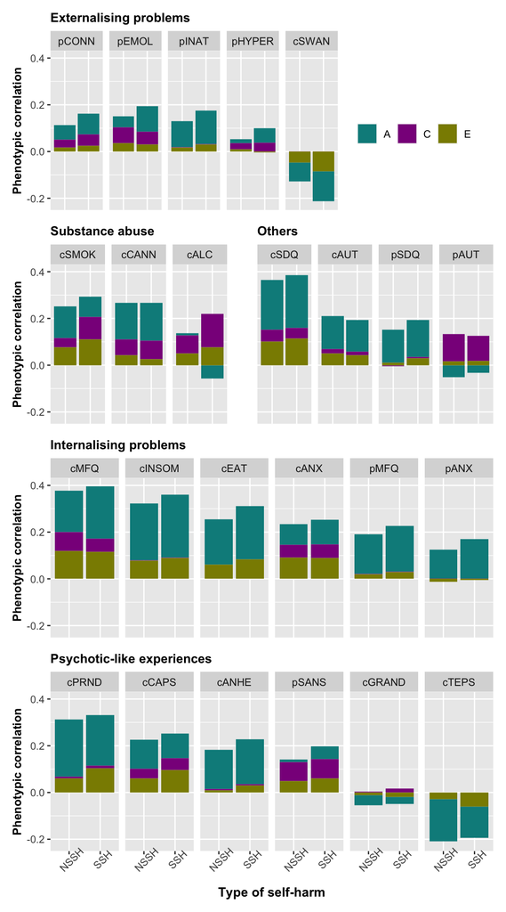

```r
pheno_plot
```

## Plot Figure 3: Graphical representation of Table S8

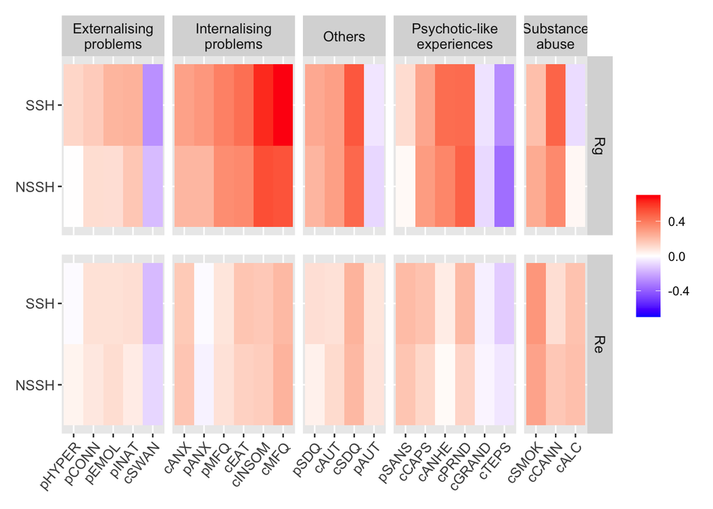

```r
######## now plot the second graph for rG, rC and rE #######
path_rg<-"/Users/kai/OneDrive - King's College London/PhD/TEDS_project/results/14_reanalyses_trivariate/trivariate_estimates_with_CI_16_June_2020.xlsx"
corr <- path_rg %>%
  excel_sheets() %>%
  set_names() %>%
  map_df(read_excel,
         path = path_rg,
         .id = "trait") #id = column name for the sheet name as column values

corr2<-as.data.frame(corr)
colnames(corr2)[2]<-"correlation"
corr_plot <- corr2 %>%
            add_column(typecor=ifelse(grepl("ACE.Rph",corr2$correlation),
                                      "Rph",
                               ifelse(grepl("ACE.Ra",corr2$correlation),
                                      "Ra",
                               ifelse(grepl("ACE.Rc",corr2$correlation),
                                      "Rc", "Re")))) %>%
            add_column(selfharm=rep(c("NSSH","SSH"),96))%>%
            add_column(unique_ID=paste(corr2$trait,corr2$selfharm,sep="_"))%>%
            add_column(rater=ifelse(grepl("c",corr2$trait),"child","parent"))



corr_plot<-corr_plot%>%
  add_column(trait_category=ifelse(corr_plot$trait=="pSDQ"|
                                     corr_plot$trait=="cSDQ"|
                                     corr_plot$trait=="pAUT"|
                                     corr_plot$trait=="cAUT","Others",
                                   ifelse(corr_plot$trait=="pCONN"|
                                            corr_plot$trait=="pEMOLv2"|
                                            corr_plot$trait=="pINAT"|
                                            corr_plot$trait=="pHYPER"|
                                            corr_plot$trait=="cSWAN","Externalising problems",
                                          ifelse(corr_plot$trait=="pMFQ"|
                                                   corr_plot$trait=="cMFQv2"|
                                                   corr_plot$trait=="pANX"|
                                                   corr_plot$trait=="cANX"|
                                                   corr_plot$trait=="cEAT"|
                                                   corr_plot$trait=="cINSOM","Internalising problems",
                                                 ifelse(corr_plot$trait=="cCAPS"|
                                                          corr_plot$trait=="cGRAND"|
                                                          corr_plot$trait=="cTEPS"|
                                                          corr_plot$trait=="cANHE"|
                                                          corr_plot$trait=="cPRND"|
                                                          corr_plot$trait=="pSANS","Psychotic-like experiences",
                                                        ifelse(corr_plot$trait=="cSMOK"|
                                                                 corr_plot$trait=="cALC"|
                                                                 corr_plot$trait=="cCANN","Substance abuse","No"))))))

corr_plot$trait_ra = factor(corr_plot$trait, levels=c("pHYPER",'pCONN',"pEMOLv2",'pINAT','pSDQ',"cAUT","cSDQ","pAUT","cSWAN",
                                                 "cANX","pANX","pMFQ","cEAT","cINSOM","cMFQv2",
                                                 "pSANS","cCAPS","cANHE","cPRND","cGRAND","cTEPS",
                                                 "cSMOK","cCANN","cALC"),
                            labels=c("pHYPER",'pCONN',"pEMOL",'pINAT','pSDQ',"cAUT","cSDQ","pAUT","cSWAN",
                                     "cANX","pANX","pMFQ","cEAT","cINSOM","cMFQ",
                                     "pSANS","cCAPS","cANHE","cPRND","cGRAND","cTEPS",
                                     "cSMOK","cCANN","cALC"))
#### try to plot a heatmap suggested by reviewer ######
#https://jcoliver.github.io/learn-r/006-heatmaps.html
#https://stackoverflow.com/questions/13016022/ggplot2-heatmaps-using-different-gradients-for-categories
re_heat<-ggplot(corr_plot[corr_plot$typecor=="Re",],
               mapping=aes(fill=estimate, x=trait_ra,y=selfharm))+
  geom_tile()+
  facet_grid(vars(typecor),vars(trait_category),scales = "free_x", space = "free_x",
             labeller=labeller(trait_category=label_wrap_gen(width=10),
                               typecor=c(Re="Re")))+
  theme(axis.text.x = element_text(angle =50, hjust = 1, size=10, face="plain"),
        strip.text.x=element_blank(),
        axis.title=element_blank(),
        strip.text= element_text(size = 10, face="plain"),
        axis.text.y=element_text(size=10, face="plain"))+
  scale_fill_gradient2(low = "blue", high = "red", mid = "white",
                       midpoint = 0, limit = c(-0.7,0.7), space = "Lab",
                       name="")



ra_heat<-ggplot(corr_plot[corr_plot$typecor=="Ra",],
                mapping=aes(fill=estimate, x=trait_ra,y=selfharm))+
  geom_tile()+
  facet_grid(vars(typecor),vars(trait_category),scales = "free_x", space = "free_x",
             labeller=labeller(trait_category=label_wrap_gen(width=10),
                               typecor=c(Ra="Rg")))+
  theme(axis.title=element_blank(),
        axis.text.x=element_blank(),
        axis.ticks.x=element_blank(),
        legend.title = element_blank(),
        strip.text= element_text(size = 10, face="plain"),
        axis.text.y=element_text(size=10, face="plain"),
        legend.position = "none")+
  scale_fill_gradient2(low = "blue", high = "red", mid = "white",
                       midpoint = 0, limit = c(-0.7,0.7), space = "Lab",
                       name="")





rare_heat<-(ra_heat/re_heat)+plot_layout(guides="collect")
rare_heat
```

## Table S9: Goodness of fit tests in trivariate analyses

Code to compile goodness of fit tests results into a table

```r
#now read the chisquare results
path_chi<-"/Users/kai/OneDrive - King's College London/PhD/TEDS_project/results/14_reanalyses_trivariate/trivariate_constrained_results_16_June_2020.xlsx"

chi <- path_chi %>%
  excel_sheets() %>%
  set_names() %>%
  map_df(read_excel,
         path = path_chi,
         .id = "trait") #id = column name for the sheet name as column values


chi2<-chi%>%
  add_column(trait_category=ifelse(chi$trait=="pSDQ"|
                                     chi$trait=="cSDQ"|
                                     chi$trait=="pAUT"|
                                     chi$trait=="cAUT", "Others",
                                   ifelse(chi$trait=="pCONN"|
                                            chi$trait=="pEMOLv2"|
                                            chi$trait=="pINAT"|
                                            chi$trait=="pHYPER"|
                                            chi$trait=="cSWAN","Externalising problems",
                                          ifelse(chi$trait=="pMFQ"|
                                                   chi$trait=="cMFQv2"|
                                                   chi$trait=="pANX"|
                                                   chi$trait=="cANX"|
                                                   chi$trait=="cEAT"|
                                                   chi$trait=="cINSOM","Internalising problems",
                                                 ifelse(chi$trait=="cCAPS"|
                                                          chi$trait=="cGRAND"|
                                                          chi$trait=="cTEPS"|
                                                          chi$trait=="cANHE"|
                                                          chi$trait=="cPRND"|
                                                          chi$trait=="pSANS","Psychotic-like experiences",
                                                        ifelse(chi$trait=="cSMOK"|
                                                                 chi$trait=="cALC"|
                                                                 chi$trait=="cCANN","Substance abuse",NA))))))%>%
  select(trait_category,`...1`,trait,minus2LL,df,AIC,diffLL,diffdf,p)%>%
  arrange(trait_category)

chi_p<-chi2[!is.na(chi2$p),]
chi_p$q<-p.adjust(chi_p$p,method="fdr")

chi_merged<-merge(x = chi2, y = chi_p[ , c("p", "q")], by = "p", all.x=T, all.y=T)%>%
  select(trait_category,trait,`...1`,minus2LL,df,AIC,diffLL,diffdf,p,q)%>%
  arrange(`...1`)%>%
  arrange(trait)%>%
  arrange(trait_category)


chi_merged$minus2LL<-specify_decimal(chi_merged$minus2LL,2)
chi_merged$AIC<-specify_decimal(chi_merged$AIC,2)
chi_merged$diffLL<-specify_decimal(chi_merged$diffLL,2)
chi_merged$trait[chi_merged$trait=="pEMOLv2"]<-"pEMOL"
chi_merged$trait[chi_merged$trait=="cMFQv2"]<-"cMFQ"
chi_merged$p[which(is.na(chi_merged$p))]<-chi_merged$p[which(is.na(chi_merged$p))+1]
chi_merged$q[which(is.na(chi_merged$q))]<-chi_merged$q[which(is.na(chi_merged$q))+1]
chi_merged$diffdf[which(is.na(chi_merged$diffdf))]<-chi_merged$diffdf[which(is.na(chi_merged$diffdf))+1]
chi_merged$diffLL[which(chi_merged$diffLL=="NA")] <- chi_merged$diffLL[which(chi_merged$diffLL=="NA")+1]


colnames(chi_merged)<-c("Category","Measure","Model", "-2 Log Likelihood","df","AIC","∆ -2 Log Likelihood",
                        "∆ df", "p-value", "q-value")

chi_merged$Model[chi_merged$Model==1]<-"ACE model"
chi_merged$Model[chi_merged$Model==2]<-"Constrained model"

knitr::kable(chi_merged,digits=3)%>%
  kableExtra::kable_styling(font_size = 12)%>%
  kableExtra::collapse_rows()
```

[output not shown]

```r
#save the table to an excel file
write.xlsx(chi_merged,"chi_test_2LL_2dp_25_July_2020.xlsx")
```